# 1 Dentists, Adult Smoking, and Excessive Drinking

A Cross-sectional Study from CHR 2018 - 2024

Author

Sarah Albalawi

Published

2025-10-28

# R Setup

```r
knitr::opts_chunk$set(comment = NA)

library(janitor)
library(dplyr)
library(readr)
library(magrittr)
library(Hmisc)
library(knitr)
library(naniar)
library(easystats)
library(tableone)
library(mosaic)
library(gt)
library(Epi)
library(Matching)
library(arm)
library(cobalt)
library(broom)
library(survival)
library(ggplot2)
library(mice)
library(patchwork)
library(twang)
library(car)
library(rbounds)
library(tidyverse)

theme_set(theme_bw())
```

### Loading CHR Data

We will load two data sets from the County Health Ranking source: CHR from year 2024 and CHR from year 2018.

```r
chr24_raw <- read_csv("analytic_data2018_0.csv", skip = 1, show_col_types = FALSE)
dim(chr24_raw)
```

```
[1] 3194  508
```

```r
chr18_raw <- read_csv("analytic_data2024.csv", skip = 1, show_col_types = FALSE)

dim(chr18_raw)
```

```
[1] 3195  770
```

# 2 Data Management

## 2.1 Joining data sets

```r
chr24_var <- chr24_raw|> dplyr::select(
    fipscode,
    v009_rawvalue,
    v049_rawvalue)
```

```r
chr18_var <- chr18_raw|> dplyr::select(
    fipscode,
    v002_rawvalue,
    v036_rawvalue,
    v042_rawvalue,
    v133_rawvalue,
    v085_rawvalue,
    v004_rawvalue,
    v088_rawvalue,
    v062_other_data_1,
    v069_rawvalue,
    v023_rawvalue,
    v044_rawvalue,
    v140_rawvalue,
    v147_rawvalue,
    v060_rawvalue,
    v143_rawvalue,
    v021_rawvalue,
    v141_rawvalue,
    v153_rawvalue,
    v154_rawvalue,
    v052_rawvalue,
    v053_rawvalue,
    v054_rawvalue,
    v055_rawvalue,
    v081_rawvalue,
    v056_rawvalue,
    v126_rawvalue,
    v057_rawvalue,
    v058_rawvalue,
    v070_rawvalue,
    v011_rawvalue,
    v063_rawvalue)
```

Now we will joing the two table to produce our initial working data set `chr_1`.

```r
chr_1 <- chr18_var |>
  left_join(chr24_var, by= "fipscode")

dim(chr_1)
```

```
[1] 3195   34
```

Our joint data set has 3,195 observations (counties) and 34 variables (health measures).

## The Codebook

The data file includes 3,195 observations (counties), on 34 variables (health measures).

| Variable | Description | Notes | Year |
| --- | --- | --- | --- |
| `fipscode` | 5-digit FIPS Code |  |  |
| `v088_rawvalue` | Number of dentists per 1000 population | **Binary Exposure**: High proportion vs Low proportion | 2018 |
| `v009_rawvalue` | Adult Smoking prevalence % | **Quantitative Outcome 1** | 2024 |
| `v049_rawvalue` | Excessive Drinking prevalence % | **Quantitative outcome 2** | 2024 |
| `v052_rawvalue` | % Below 18 Years of Age proportion | *Covariate* | 2018 |
| `v053_rawvalue` | % 65 and Older proportion | *Covariate* | 2018 |
| `v054_rawvalue` | % Non-Hispanic Black proportion | *Covariate* | 2018 |
| `v055_rawvalue` | % American Indian or Alaska Native proportion | *Covariate* | 2018 |
| `v081_rawvalue` | % Asian proportion | *Covariate* | 2018 |
| `v056_rawvalue` | % Hispanic proportion | *Covariate* | 2018 |
| `v126_rawvalue` | % Non-Hispanic White proportion | *Covariate* | 2018 |
| `v057_rawvalue` | % Female proportion | *Covariate* | 2018 |
| `v058_rawvalue` | % Rural | *Covariate* | 2018 |
| `v002_rawvalue` | % Poor or Fair Health | *Covariate* | 2018 |
| `v036_rawvalue` | Poor Physical Health Days | *Covariate* | 2018 |
| `v042_rawvalue` | Poor Mental Health Days | *Covariate* | 2018 |
| `v133_rawvalue` | Food Environment Index | *Covariate* | 2018 |
| `v085_rawvalue` | Uninsured population % | *Covariate* | 2018 |
| `v004_rawvalue` | Primary Care Physicians per population | *Covariate* | 2018 |
| `v062_other_data_1` | Ratio of population to mental health providers | *Covariate* | 2018 |
| `v021_rawvalue` | High School Completion % | *Covariate* | 2018 |
| `v069_rawvalue` | Some College % | *Covariate* | 2018 |
| `v023_rawvalue` | Unemployment % | *Covariate* | 2018 |
| `v044_rawvalue` | Income Inequality | *Covariate* | 2018 |
| `v140_rawvalue` | Social Associations | *Covariate* | 2018 |
| `v070_rawvalue` | Physical Inactivity days | *Covariate* | 2018 |
| `v011_rawvalue` | Adult Obesity prevalence % | *Covariate* | 2018 |
| `v060_rawvalue` | Diabetes Prevalence % | *Covariate* | 2018 |
| `v143_rawvalue` | Insufficient Sleep proportion % | *Covariate* | 2018 |
| `v141_rawvalue` | Residential Segregation - Black/White | *Covariate* | 2018 |
| `v147_rawvalue` | Life Expectancy (years) | *Covariate* | 2018 |
| `v063_rawvalue` | Median Household Income | *Covariate* | 2018 |
| `v153_rawvalue` | Home ownership | *Covariate* | 2018 |
| `v154_rawvalue` | Severe Housing Cost Burden | *Covariate* | 2018 |

> Note: The analysis will include one exposure and two outcome variables.

## 2.2 Renaming the variables

```r
chr_1 <- chr_1 |>
  mutate(dentist_grp = v088_rawvalue*100,
         smoking_prop = v009_rawvalue*100,
         drinking_prop = v049_rawvalue*100)|>
  rename(below_18 = v052_rawvalue,
         above_65 = v053_rawvalue,
         black = v054_rawvalue,
         native = v055_rawvalue,
         asian = v081_rawvalue,
         hispanic = v056_rawvalue,
         white = v126_rawvalue,
         female = v057_rawvalue,
         rural = v058_rawvalue,
         poor_health = v002_rawvalue,
         poor_physical = v036_rawvalue,
         poor_mental = v042_rawvalue,
         food_index = v133_rawvalue,
         uninsured = v085_rawvalue,
         primary_care = v004_rawvalue,
         mental_care = v062_other_data_1,
         highschool_grad  = v021_rawvalue,
         some_college = v069_rawvalue,
         unemployment = v023_rawvalue,
         income_inequality = v044_rawvalue,
         social_score = v140_rawvalue,
         inactivity = v070_rawvalue,
         obesity = v011_rawvalue,
         diabetes = v060_rawvalue,
         insuff_sleep = v143_rawvalue,
         segregation = v141_rawvalue,
         life_expectancy = v147_rawvalue,
         household_income = v063_rawvalue,
         home_ownership = v153_rawvalue,
         housing_burden = v154_rawvalue )|>
  dplyr::select(-v088_rawvalue, -v009_rawvalue , -v049_rawvalue)
```

Checking the new names:

```r
names(chr_1)
```

```
 [1] "fipscode"          "poor_health"       "poor_physical"
 [4] "poor_mental"       "food_index"        "uninsured"
 [7] "primary_care"      "mental_care"       "some_college"
[10] "unemployment"      "income_inequality" "social_score"
[13] "life_expectancy"   "diabetes"          "insuff_sleep"
[16] "highschool_grad"   "segregation"       "home_ownership"
[19] "housing_burden"    "below_18"          "above_65"
[22] "black"             "native"            "asian"
[25] "hispanic"          "white"             "female"
[28] "rural"             "inactivity"        "obesity"
[31] "household_income"  "dentist_grp"       "smoking_prop"
[34] "drinking_prop"
```

> The new names look reasonable and are free from spelling errors.

## 2.3 Categorizing Exposure `dentist_grp`

```r
summary(chr_1$dentist_grp)
```

```
   Min. 1st Qu.  Median    Mean 3rd Qu.    Max.    NA's
0.00000 0.02760 0.04391 0.04867 0.06495 0.81642      87
```

We will use the first quartile (0.028) and third quartile (0.065) as cut points to dichotomize the `dentist_grp` variable.

```r
chr_1 <- chr_1 |>
  mutate(dentist_grp = case_when(
    dentist_grp <= 0.02760 ~ "Low",
    dentist_grp >= 0.06495 ~ "High")) |>
  mutate(dentist_grp = factor(dentist_grp))

chr_1 |> count(dentist_grp)
```

```
# A tibble: 3 × 2
  dentist_grp     n
  <fct>       <int>
1 High          777
2 Low           777
3 <NA>         1641
```

```r
chr_1 <- chr_1 |>
  mutate(dentist_n = as.numeric(dentist_grp),
         dentist_n = dentist_n - 1)

chr_1 |> count(dentist_n)
```

```
# A tibble: 3 × 2
  dentist_n     n
      <dbl> <int>
1         0   777
2         1   777
3        NA  1641
```

We have 777 counties in each group.

## 2.4 Numeric Summaries Before Imputation

```r
describe(chr_1)
```

```
chr_1

 35  Variables      3195  Observations
--------------------------------------------------------------------------------
fipscode
       n  missing distinct
    3195        0     3195

lowest : 00000 01000 01001 01003 01005, highest: 56037 56039 56041 56043 56045
--------------------------------------------------------------------------------
poor_health
       n  missing distinct     Info     Mean  pMedian      Gmd      .05
    3195        0      237        1   0.1768    0.174  0.05052   0.1160
     .10      .25      .50      .75      .90      .95
  0.1254   0.1420   0.1680   0.2070   0.2380   0.2580

lowest : 0.084 0.087 0.089 0.091 0.093, highest: 0.351 0.359 0.364 0.375 0.38
--------------------------------------------------------------------------------
poor_physical
       n  missing distinct     Info     Mean  pMedian      Gmd      .05
    3195        0     3194        1    3.888    3.871    0.734    2.915
     .10      .25      .50      .75      .90      .95
   3.065    3.385    3.866    4.333    4.739    4.977

lowest : 2.26179 2.33164 2.39068 2.3946  2.41979
highest: 6.08336 6.0868  6.1734  6.44954 6.83683
--------------------------------------------------------------------------------
poor_mental
       n  missing distinct     Info     Mean  pMedian      Gmd      .05
    3195        0     3194        1    5.212    5.219   0.6926    4.122
     .10      .25      .50      .75      .90      .95
   4.410    4.814    5.229    5.626    5.990    6.194

lowest : 3.18554 3.21723 3.53009 3.54504 3.54712
highest: 7.07808 7.15042 7.17393 7.30487 7.38881
--------------------------------------------------------------------------------
food_index
       n  missing distinct     Info     Mean  pMedian      Gmd      .05
    3160       35       82    0.999    7.543     7.65    1.291      5.3
     .10      .25      .50      .75      .90      .95
```

[output cut: 248 more lines]

```
--------------------------------------------------------------------------------
drinking_prop
       n  missing distinct     Info     Mean  pMedian      Gmd      .05
    3192        3     3191        1    17.43    17.39    3.677    12.29
     .10      .25      .50      .75      .90      .95
   13.14    15.10    17.40    19.68    21.47    22.92

lowest : 9.26516 9.28781 9.40767 9.48465 9.52642
highest: 27.8133 28.0047 28.0822 28.1579 29.4401
--------------------------------------------------------------------------------
dentist_n
       n  missing distinct     Info      Sum     Mean
    1554     1641        2     0.75      777      0.5

--------------------------------------------------------------------------------
```

## 2.5 Dealing with Missingness

```r
miss_var_summary(chr_1)
```

```
# A tibble: 35 × 3
   variable          n_miss pct_miss
   <chr>              <int>    <num>
 1 dentist_grp         1641   51.4
 2 dentist_n           1641   51.4
 3 segregation         1067   33.4
 4 highschool_grad      678   21.2
 5 mental_care          185    5.79
 6 primary_care         157    4.91
 7 life_expectancy       73    2.28
 8 food_index            35    1.10
 9 income_inequality     15    0.469
10 housing_burden         5    0.156
# ℹ 25 more rows
```

The `segregation` variable constitutes 33.4% of the missing data, followed by highschool_grd (21.2%), `mental_care` (5.79%), `primary_care` (4.91%), life_expectancy (2.28%), `food_index` (1.10%). Other variables with minimal missingness (<1%) include `income_inequality`, `housing_burden`, `insuff_sleep`, `uninsured`, `unemployment`, `household_income`.

### 2.5.1 Filter Complete Cases For Exposure `dentist_prop`

```r
chr_simp <- chr_1 |>
  filter(!is.na(dentist_grp))|>
  filter(!is.na(dentist_n))
```

```r
n_miss(chr_simp$dentist_n)
```

```
[1] 0
```

### 2.5.2 Single Imputation for Covariates

```r
chr_simp <-
  mice(chr_simp, m = 1, seed = 500, print = FALSE) |>
  complete() |>
  tibble()
```

```r
miss_var_summary(chr_simp)
```

```
# A tibble: 35 × 3
   variable      n_miss pct_miss
   <chr>          <int>    <num>
 1 fipscode           0        0
 2 poor_health        0        0
 3 poor_physical      0        0
 4 poor_mental        0        0
 5 food_index         0        0
 6 uninsured          0        0
 7 primary_care       0        0
 8 mental_care        0        0
 9 some_college       0        0
10 unemployment       0        0
# ℹ 25 more rows
```

There are no missing observation in the semi-final working data set `chr_simp`.

# 3 Final Variable Selection

## 3.1 Check Correlation

```r
res <- correlation(chr_simp, method = "spearman")

res
```

```
# Correlation Matrix (spearman-method)

Parameter1        |        Parameter2 |       rho |         95% CI |        S |         p
-----------------------------------------------------------------------------------------
poor_health       |     poor_physical |      0.94 | [ 0.93,  0.95] | 3.77e+07 | < .001***
poor_health       |       poor_mental |      0.75 | [ 0.73,  0.77] | 1.54e+08 | < .001***
poor_health       |        food_index |     -0.68 | [-0.70, -0.65] | 1.05e+09 | < .001***
poor_health       |         uninsured |      0.54 | [ 0.51,  0.58] | 2.85e+08 | < .001***
poor_health       |      primary_care |     -0.40 | [-0.44, -0.36] | 8.75e+08 | < .001***
poor_health       |       mental_care |      0.37 | [ 0.33,  0.42] | 3.93e+08 | < .001***
poor_health       |      some_college |     -0.79 | [-0.81, -0.77] | 1.12e+09 | < .001***
poor_health       |      unemployment |      0.47 | [ 0.43,  0.51] | 3.29e+08 | < .001***
poor_health       | income_inequality |      0.45 | [ 0.41,  0.49] | 3.41e+08 | < .001***
poor_health       |      social_score |     -0.13 | [-0.18, -0.08] | 7.05e+08 | < .001***
poor_health       |   life_expectancy |     -0.81 | [-0.83, -0.79] | 1.13e+09 | < .001***
poor_health       |          diabetes |      0.94 | [ 0.93,  0.94] | 3.96e+07 | < .001***
poor_health       |      insuff_sleep |      0.79 | [ 0.77,  0.80] | 1.34e+08 | < .001***
poor_health       |   highschool_grad |      0.01 | [-0.04,  0.06] | 6.18e+08 | > .999
poor_health       |       segregation |     -0.30 | [-0.35, -0.25] | 8.14e+08 | < .001***
poor_health       |    home_ownership |     -0.06 | [-0.11, -0.01] | 6.62e+08 | > .999
poor_health       |    housing_burden |  1.45e-03 | [-0.05,  0.05] | 6.25e+08 | > .999
poor_health       |          below_18 |      0.16 | [ 0.11,  0.21] | 5.25e+08 | < .001***
poor_health       |          above_65 |     -0.10 | [-0.15, -0.04] | 6.85e+08 | 0.021*
poor_health       |             black |      0.30 | [ 0.25,  0.35] | 4.38e+08 | < .001***
poor_health       |            native | -7.28e-03 | [-0.06,  0.04] | 6.30e+08 | > .999
poor_health       |             asian |     -0.36 | [-0.41, -0.32] | 8.53e+08 | < .001***
poor_health       |          hispanic |     -0.06 | [-0.11, -0.01] | 6.62e+08 | > .999
poor_health       |             white |     -0.29 | [-0.34, -0.25] | 8.09e+08 | < .001***
poor_health       |            female |      0.05 | [ 0.00,  0.10] | 5.94e+08 | > .999
poor_health       |             rural |      0.33 | [ 0.28,  0.37] | 4.21e+08 | < .001***
poor_health       |        inactivity |      0.88 | [ 0.87,  0.89] | 7.60e+07 | < .001***
poor_health       |           obesity |      0.69 | [ 0.66,  0.71] | 1.96e+08 | < .001***
poor_health       |  household_income |     -0.78 | [-0.80, -0.76] | 1.11e+09 | < .001***
poor_health       |      smoking_prop |      0.71 | [ 0.69,  0.74] | 1.80e+08 | < .001***
poor_health       |     drinking_prop |     -0.69 | [-0.72, -0.66] | 1.06e+09 | < .001***
poor_health       |         dentist_n |      0.44 | [ 0.39,  0.48] | 3.53e+08 | < .001***
poor_physical     |       poor_mental |      0.85 | [ 0.84,  0.87] | 9.12e+07 | < .001***
poor_physical     |        food_index |     -0.64 | [-0.67, -0.61] | 1.03e+09 | < .001***
poor_physical     |         uninsured |      0.46 | [ 0.42,  0.50] | 3.38e+08 | < .001***
poor_physical     |      primary_care |     -0.41 | [-0.45, -0.36] | 8.80e+08 | < .001***
```

[output cut: 480 more lines]

```
inactivity        |     drinking_prop |     -0.62 | [-0.65, -0.58] | 1.01e+09 | < .001***
inactivity        |         dentist_n |      0.50 | [ 0.46,  0.53] | 3.14e+08 | < .001***
obesity           |  household_income |     -0.66 | [-0.69, -0.63] | 1.04e+09 | < .001***
obesity           |      smoking_prop |      0.62 | [ 0.58,  0.65] | 2.40e+08 | < .001***
obesity           |     drinking_prop |     -0.49 | [-0.53, -0.45] | 9.35e+08 | < .001***
obesity           |         dentist_n |      0.45 | [ 0.40,  0.49] | 3.47e+08 | < .001***
household_income  |      smoking_prop |     -0.66 | [-0.69, -0.63] | 1.04e+09 | < .001***
household_income  |     drinking_prop |      0.61 | [ 0.58,  0.64] | 2.45e+08 | < .001***
household_income  |         dentist_n |     -0.42 | [-0.47, -0.38] | 8.91e+08 | < .001***
smoking_prop      |     drinking_prop |     -0.47 | [-0.51, -0.43] | 9.18e+08 | < .001***
smoking_prop      |         dentist_n |      0.32 | [ 0.27,  0.37] | 4.25e+08 | < .001***
drinking_prop     |         dentist_n |     -0.39 | [-0.43, -0.35] | 8.69e+08 | < .001***

p-value adjustment method: Holm (1979)
Observations: 1554
```

The variables with a correlation of 0.8 or more (or -0.8 or less) are:

```r
chr_fin <- chr_simp |>
  dplyr::select(-fipscode, -poor_health, -poor_physical, -inactivity)

dim(chr_fin)
```

```
[1] 1554   31
```

# 4 Table 1

setting up table 1:

```r
myVars  <- c("poor_mental", "food_index",
                   "uninsured", "primary_care", "mental_care",
                   "highschool_grad", "some_college", "unemployment", "income_inequality",
                   "social_score", "life_expectancy", "insuff_sleep",
                   "home_ownership", "housing_burden",
                   "below_18","above_65", "black", "native", "asian", "hispanic",
                   "white", "female", "rural", "obesity", "household_income", "smoking_prop", "drinking_prop")


t1 <- tableone::CreateTableOne(
          data = chr_fin,
          vars = myVars,
          strata = c("dentist_grp"))

table_one_text <- print(
  t1,
  showAllLevels = TRUE,
  quote         = FALSE,
  noSpaces      = FALSE,
  printToggle   = FALSE
)


knitr::kable(
  table_one_text,
  format   = "html",
  caption  = "Comparison by Dentist Proportion"
)
```

Comparison by Dentist Proportion

|  | level | High | Low | p | test |
| --- | --- | --- | --- | --- | --- |
| n |  | 777 | 777 |  |  |
| poor_mental (mean (SD)) |  | 5.02 (0.59) | 5.35 (0.64) | <0.001 |  |
| food_index (mean (SD)) |  | 7.90 (1.18) | 7.19 (1.38) | <0.001 |  |
| uninsured (mean (SD)) |  | 0.09 (0.04) | 0.13 (0.06) | <0.001 |  |
| primary_care (mean (SD)) |  | 0.00 (0.00) | 0.00 (0.00) | <0.001 |  |
| mental_care (mean (SD)) |  | 547.08 (975.87) | 2390.97 (2778.69) | <0.001 |  |
| highschool_grad (mean (SD)) |  | 0.86 (0.07) | 0.89 (0.08) | <0.001 |  |
| some_college (mean (SD)) |  | 0.67 (0.10) | 0.54 (0.12) | <0.001 |  |
| unemployment (mean (SD)) |  | 0.03 (0.01) | 0.04 (0.01) | 0.151 |  |
| income_inequality (mean (SD)) |  | 4.54 (0.74) | 4.61 (0.95) | 0.085 |  |
| social_score (mean (SD)) |  | 10.97 (5.14) | 10.85 (7.36) | 0.701 |  |
| life_expectancy (mean (SD)) |  | 77.26 (3.57) | 74.98 (3.37) | <0.001 |  |
| insuff_sleep (mean (SD)) |  | 0.33 (0.04) | 0.35 (0.04) | <0.001 |  |
| home_ownership (mean (SD)) |  | 0.68 (0.10) | 0.76 (0.08) | <0.001 |  |
| housing_burden (mean (SD)) |  | 0.13 (0.04) | 0.10 (0.03) | <0.001 |  |
| below_18 (mean (SD)) |  | 0.21 (0.03) | 0.22 (0.04) | 0.632 |  |
| above_65 (mean (SD)) |  | 0.20 (0.05) | 0.22 (0.05) | <0.001 |  |
| black (mean (SD)) |  | 0.08 (0.12) | 0.10 (0.16) | 0.004 |  |
| native (mean (SD)) |  | 0.04 (0.10) | 0.02 (0.06) | <0.001 |  |
| asian (mean (SD)) |  | 0.04 (0.05) | 0.01 (0.01) | <0.001 |  |
| hispanic (mean (SD)) |  | 0.11 (0.11) | 0.10 (0.15) | 0.036 |  |
| white (mean (SD)) |  | 0.72 (0.20) | 0.76 (0.21) | <0.001 |  |
| female (mean (SD)) |  | 0.50 (0.02) | 0.49 (0.03) | <0.001 |  |
| rural (mean (SD)) |  | 0.38 (0.33) | 0.89 (0.19) | <0.001 |  |
| obesity (mean (SD)) |  | 0.34 (0.05) | 0.39 (0.04) | <0.001 |  |
| household_income (mean (SD)) |  | 71992.92 (19356.32) | 57529.52 (12919.78) | <0.001 |  |
| smoking_prop (mean (SD)) |  | 16.41 (3.68) | 18.78 (3.76) | <0.001 |  |
| drinking_prop (mean (SD)) |  | 18.83 (3.24) | 16.26 (2.91) | <0.001 |  |

The low dentist group counties have more proportions of uninsured populations (0.13 vs 0.09 ), lower college education (0.54 vs 0.67), lower life expectancy (74.9 vs 77.3), more rural areas (0.89 vs 0.38), **more** `smoking prevalence` (18.8 vs 16.4) and **lower** `excessive drinking` (16.3 vs 18.8).

# 5 Propensity Score Assessment

## 5.1 Calculating and Evaluating PS Balance

To calculate the PS, we will build a logistic model with the binary exposure as the outcome and the covariates as the predictors.

```r
psmodel0 <- glm(dentist_grp ~  poor_mental + food_index + uninsured + income_inequality +
                  primary_care + mental_care + highschool_grad + some_college + unemployment +
                  social_score + life_expectancy + insuff_sleep + segregation + home_ownership +
                  housing_burden + below_18 + above_65 + black + native + asian + hispanic +
                  white + female + rural + obesity + household_income,
                family = binomial(), data= chr_fin)

model_parameters(psmodel0) |>
  gt() |> fmt_number(decimals = 3) |>
  opt_stylize(style = 1, color = "pink")
```

| Parameter | Coefficient | SE | CI | CI_low | CI_high | z | df_error | p |
| --- | --- | --- | --- | --- | --- | --- | --- | --- |
| (Intercept) | −0.289 | 7.033 | 0.950 | −14.370 | 13.621 | −0.041 | Inf | 0.967 |
| poor_mental | 0.229 | 0.283 | 0.950 | −0.325 | 0.785 | 0.811 | Inf | 0.417 |
| food_index | −0.196 | 0.107 | 0.950 | −0.409 | 0.012 | −1.826 | Inf | 0.068 |
| uninsured | 12.491 | 3.018 | 0.950 | 6.653 | 18.494 | 4.139 | Inf | 0.000 |
| income_inequality | 0.143 | 0.161 | 0.950 | −0.167 | 0.464 | 0.890 | Inf | 0.373 |
| primary_care | −3,235.569 | 350.427 | 0.950 | −3,940.793 | −2,564.907 | −9.233 | Inf | 0.000 |
| mental_care | 0.000 | 0.000 | 0.950 | 0.000 | 0.000 | 2.513 | Inf | 0.012 |
| highschool_grad | −0.445 | 1.344 | 0.950 | −3.212 | 2.094 | −0.331 | Inf | 0.741 |
| some_college | −0.572 | 1.270 | 0.950 | −3.064 | 1.920 | −0.451 | Inf | 0.652 |
| unemployment | −18.456 | 10.540 | 0.950 | −39.187 | 2.206 | −1.751 | Inf | 0.080 |
| social_score | −0.018 | 0.015 | 0.950 | −0.048 | 0.011 | −1.215 | Inf | 0.224 |
| life_expectancy | −0.011 | 0.048 | 0.950 | −0.104 | 0.085 | −0.225 | Inf | 0.822 |
| insuff_sleep | 3.596 | 5.940 | 0.950 | −8.048 | 15.264 | 0.605 | Inf | 0.545 |
| segregation | −0.022 | 0.007 | 0.950 | −0.035 | −0.009 | −3.336 | Inf | 0.001 |
| home_ownership | 6.351 | 2.013 | 0.950 | 2.421 | 10.306 | 3.155 | Inf | 0.002 |
| housing_burden | −6.008 | 4.090 | 0.950 | −14.047 | 2.009 | −1.469 | Inf | 0.142 |
| below_18 | −14.298 | 4.826 | 0.950 | −23.729 | −4.787 | −2.963 | Inf | 0.003 |
| above_65 | −14.052 | 3.834 | 0.950 | −21.546 | −6.495 | −3.665 | Inf | 0.000 |
| black | −1.113 | 4.465 | 0.950 | −10.265 | 8.398 | −0.249 | Inf | 0.803 |
| native | −8.765 | 4.815 | 0.950 | −18.599 | 1.319 | −1.820 | Inf | 0.069 |
| asian | −26.237 | 15.047 | 0.950 | −57.152 | −2.854 | −1.744 | Inf | 0.081 |
| hispanic | −2.042 | 4.303 | 0.950 | −10.832 | 7.051 | −0.474 | Inf | 0.635 |
| white | −1.641 | 4.644 | 0.950 | −11.106 | 8.138 | −0.353 | Inf | 0.724 |
| female | −1.140 | 5.360 | 0.950 | −12.093 | 9.212 | −0.213 | Inf | 0.832 |
| rural | 4.280 | 0.517 | 0.950 | 3.288 | 5.316 | 8.282 | Inf | 0.000 |
| obesity | 9.328 | 3.804 | 0.950 | 1.903 | 16.834 | 2.452 | Inf | 0.014 |
| household_income | 0.000 | 0.000 | 0.950 | 0.000 | 0.000 | 0.812 | Inf | 0.417 |

### 5.1.1 Saving Propesnsity Score

```r
chr_fin$ps0 <- psmodel0$fitted

chr_fin$linps0 <- psmodel0$linear.predictors
```

### 5.1.2 Comparing The PS Distribution of The Two Exposure Groups

```r
df_stats(ps0 + linps0 ~ dentist_grp, data = chr_fin) |>
  gt() |> fmt_number(columns = c(-n, -missing), decimals = 3) |>
  opt_stylize(style = 2, color = "pink")
```

| response | dentist_grp | min | Q1 | median | Q3 | max | mean | sd | n | missing |
| --- | --- | --- | --- | --- | --- | --- | --- | --- | --- | --- |
| ps0 | High | 0.000 | 0.004 | 0.023 | 0.124 | 0.991 | 0.139 | 0.251 | 777 | 0 |
| ps0 | Low | 0.014 | 0.829 | 0.943 | 0.984 | 1.000 | 0.861 | 0.193 | 777 | 0 |
| linps0 | High | −19.766 | −5.642 | −3.767 | −1.952 | 4.666 | −3.895 | 3.356 | 777 | 0 |
| linps0 | Low | −4.267 | 1.579 | 2.807 | 4.149 | 9.743 | 2.815 | 1.937 | 777 | 0 |

> The propensity scores here are concerning. We will need to observe the value of inflation to observe potential collinearity between the covariates.

The VIF:

```r
vif_model <- glm(dentist_grp ~  poor_mental + food_index + uninsured + income_inequality +
                  primary_care + mental_care + highschool_grad + some_college + unemployment +
                  social_score + life_expectancy + insuff_sleep + segregation + home_ownership +
                  housing_burden + below_18 + above_65 + black + native + asian + hispanic +
                  white + female + rural + obesity + household_income,
                family = binomial(), data= chr_fin)

vif(vif_model)
```

```
      poor_mental        food_index         uninsured income_inequality
         3.775083          2.288975          2.291229          2.039530
     primary_care       mental_care   highschool_grad      some_college
         1.129137          1.219127          1.369741          2.204048
     unemployment      social_score   life_expectancy      insuff_sleep
         1.920851          1.500884          3.128986          4.694362
      segregation    home_ownership    housing_burden          below_18
         1.337250          3.200085          2.076655          3.673811
         above_65             black            native             asian
         4.596523         27.541605         21.671785          2.526745
         hispanic             white            female             rural
        37.921934         87.584373          1.763807          2.417255
          obesity  household_income
         2.243732          3.681487
```

While most of the variables have low variance inflation factors, there are a few with an extremely high values (>10), which presents serious multi-collinearity. These variables are `hispanic`, `white`, `black`, and `native`. We will remove these variables from our analysis.

### 5.1.3 Fixed Propensity Score

```r
chr_fin1 <- chr_fin|>
  dplyr::select(-hispanic, -white, -black, -native, -ps0, -linps0)
```

Next, we will build the new model:

```r
psmodel00 <- glm(dentist_grp ~  poor_mental + food_index + uninsured + income_inequality +
                  primary_care + mental_care + highschool_grad + some_college + unemployment +
                  social_score + life_expectancy + insuff_sleep + segregation + home_ownership +
                  housing_burden + below_18 + above_65 + asian +
                  female + rural + obesity + household_income,
                family = binomial(), data= chr_fin1)

model_parameters(psmodel00) |>
  gt() |> fmt_number(decimals = 3) |>
  opt_stylize(style = 1, color = "pink")
```

| Parameter | Coefficient | SE | CI | CI_low | CI_high | z | df_error | p |
| --- | --- | --- | --- | --- | --- | --- | --- | --- |
| (Intercept) | −10.190 | 5.276 | 0.950 | −20.584 | 0.116 | −1.931 | Inf | 0.053 |
| poor_mental | 0.175 | 0.256 | 0.950 | −0.327 | 0.679 | 0.683 | Inf | 0.495 |
| food_index | −0.128 | 0.100 | 0.950 | −0.325 | 0.066 | −1.282 | Inf | 0.200 |
| uninsured | 10.767 | 2.457 | 0.950 | 6.056 | 15.695 | 4.382 | Inf | 0.000 |
| income_inequality | −0.046 | 0.144 | 0.950 | −0.327 | 0.240 | −0.322 | Inf | 0.748 |
| primary_care | −3,322.832 | 344.040 | 0.950 | −4,015.515 | −2,664.968 | −9.658 | Inf | 0.000 |
| mental_care | 0.000 | 0.000 | 0.950 | 0.000 | 0.000 | 2.891 | Inf | 0.004 |
| highschool_grad | 1.728 | 1.117 | 0.950 | −0.492 | 3.896 | 1.547 | Inf | 0.122 |
| some_college | −0.886 | 1.213 | 0.950 | −3.269 | 1.492 | −0.730 | Inf | 0.465 |
| unemployment | −27.947 | 9.386 | 0.950 | −46.423 | −9.585 | −2.978 | Inf | 0.003 |
| social_score | −0.010 | 0.015 | 0.950 | −0.039 | 0.019 | −0.700 | Inf | 0.484 |
| life_expectancy | 0.068 | 0.045 | 0.950 | −0.019 | 0.158 | 1.516 | Inf | 0.129 |
| insuff_sleep | 10.463 | 5.100 | 0.950 | 0.488 | 20.507 | 2.052 | Inf | 0.040 |
| segregation | −0.024 | 0.006 | 0.950 | −0.036 | −0.012 | −3.914 | Inf | 0.000 |
| home_ownership | 7.180 | 1.794 | 0.950 | 3.689 | 10.737 | 4.002 | Inf | 0.000 |
| housing_burden | −2.289 | 3.806 | 0.950 | −9.742 | 5.197 | −0.602 | Inf | 0.548 |
| below_18 | −17.897 | 4.356 | 0.950 | −26.485 | −9.390 | −4.109 | Inf | 0.000 |
| above_65 | −13.396 | 3.645 | 0.950 | −20.548 | −6.244 | −3.675 | Inf | 0.000 |
| asian | −26.238 | 12.986 | 0.950 | −52.511 | −5.981 | −2.020 | Inf | 0.043 |
| female | −0.123 | 5.055 | 0.950 | −10.218 | 9.945 | −0.024 | Inf | 0.981 |
| rural | 3.693 | 0.456 | 0.950 | 2.814 | 4.602 | 8.104 | Inf | 0.000 |
| obesity | 8.389 | 3.681 | 0.950 | 1.204 | 15.652 | 2.279 | Inf | 0.023 |
| household_income | 0.000 | 0.000 | 0.950 | 0.000 | 0.000 | −0.281 | Inf | 0.779 |

### 5.1.4 Saving Propesnsity Score

Now we will save the new propensity scores:

```r
chr_fin1$ps00 <- psmodel00$fitted

chr_fin1$linps00 <- psmodel00$linear.predictors
```

### 5.1.5 Comparing The PS Distribution of The Two Exposure Groups

```r
df_stats(ps00 + linps00 ~ dentist_grp, data = chr_fin1) |>
  gt() |> fmt_number(columns = c(-n, -missing), decimals = 3) |>
  opt_stylize(style = 2, color = "pink")
```

| response | dentist_grp | min | Q1 | median | Q3 | max | mean | sd | n | missing |
| --- | --- | --- | --- | --- | --- | --- | --- | --- | --- | --- |
| ps00 | High | 0.000 | 0.004 | 0.026 | 0.137 | 0.992 | 0.145 | 0.254 | 777 | 0 |
| ps00 | Low | 0.014 | 0.828 | 0.936 | 0.982 | 1.000 | 0.855 | 0.195 | 777 | 0 |
| linps00 | High | −20.056 | −5.575 | −3.626 | −1.842 | 4.880 | −3.839 | 3.430 | 777 | 0 |
| linps00 | Low | −4.238 | 1.570 | 2.689 | 4.015 | 10.800 | 2.707 | 1.906 | 777 | 0 |

> The propensity scores slightly improved after removing the variables with high collinearity values. However, the problem with their values being too close to 0 or 1 is visibly persistent.

#### 5.1.5.1 Fixed Propensity Score - Part 2

We will attempt to observe the impact of each covariate on the outcome individually to rule out the variable(s) that impacted the PS values.

##### 5.1.5.1.1 `poor_mental`

```r
psmodel_pm <- glm(dentist_grp ~  poor_mental,
                family = binomial(), data= chr_fin1)

model_parameters(psmodel_pm) |>
  gt() |> fmt_number(decimals = 3) |>
  opt_stylize(style = 1, color = "pink")
```

| Parameter | Coefficient | SE | CI | CI_low | CI_high | z | df_error | p |
| --- | --- | --- | --- | --- | --- | --- | --- | --- |
| (Intercept) | −4.579 | 0.458 | 0.950 | −5.487 | −3.692 | −10.004 | Inf | 0.000 |
| poor_mental | 0.883 | 0.088 | 0.950 | 0.713 | 1.057 | 10.077 | Inf | 0.000 |

##### 5.1.5.1.2 Saving Propesnsity Score

Now we will save the new propensity scores:

```r
chr_fin1$ps_pm <- psmodel_pm$fitted

chr_fin1$linps_pm <- psmodel_pm$linear.predictors
```

##### 5.1.5.1.3 Comparing The PS Distribution of The Two Exposure Groups

```r
df_stats(ps_pm + linps_pm ~ dentist_grp, data = chr_fin1) |>
  gt() |> fmt_number(columns = c(-n, -missing), decimals = 3) |>
  opt_stylize(style = 2, color = "pink")
```

| response | dentist_grp | min | Q1 | median | Q3 | max | mean | sd | n | missing |
| --- | --- | --- | --- | --- | --- | --- | --- | --- | --- | --- |
| ps_pm | High | 0.146 | 0.376 | 0.463 | 0.552 | 0.785 | 0.465 | 0.123 | 777 | 0 |
| ps_pm | Low | 0.150 | 0.448 | 0.549 | 0.632 | 0.875 | 0.535 | 0.132 | 777 | 0 |
| linps_pm | High | −1.766 | −0.505 | −0.147 | 0.209 | 1.294 | −0.151 | 0.523 | 777 | 0 |
| linps_pm | Low | −1.738 | −0.207 | 0.196 | 0.542 | 1.945 | 0.148 | 0.568 | 777 | 0 |

The `poor_mental` variable looks has two linear PS less than 0.01 and above 1.

##### 5.1.5.1.4 `food_index`

```r
psmodel_fi <- glm(dentist_grp ~  food_index,
                family = binomial(), data= chr_fin1)

model_parameters(psmodel_fi) |>
  gt() |> fmt_number(decimals = 3) |>
  opt_stylize(style = 1, color = "pink")
```

| Parameter | Coefficient | SE | CI | CI_low | CI_high | z | df_error | p |
| --- | --- | --- | --- | --- | --- | --- | --- | --- |
| (Intercept) | 3.505 | 0.360 | 0.950 | 2.812 | 4.225 | 9.727 | Inf | 0.000 |
| food_index | −0.462 | 0.047 | 0.950 | −0.555 | −0.372 | −9.911 | Inf | 0.000 |

##### 5.1.5.1.5 Saving Propesnsity Score

Now we will save the new propensity scores:

```r
chr_fin1$ps_fi <- psmodel_fi$fitted

chr_fin1$linps_fi <- psmodel_fi$linear.predictors
```

##### 5.1.5.1.6 Comparing The PS Distribution of The Two Exposure Groups

```r
df_stats(ps_fi + linps_fi ~ dentist_grp, data = chr_fin1) |>
  gt() |> fmt_number(columns = c(-n, -missing), decimals = 3) |>
  opt_stylize(style = 2, color = "pink")
```

| response | dentist_grp | min | Q1 | median | Q3 | max | mean | sd | n | missing |
| --- | --- | --- | --- | --- | --- | --- | --- | --- | --- | --- |
| ps_fi | High | 0.256 | 0.374 | 0.441 | 0.522 | 0.948 | 0.462 | 0.120 | 777 | 0 |
| ps_fi | Low | 0.247 | 0.441 | 0.522 | 0.612 | 0.971 | 0.538 | 0.137 | 777 | 0 |
| linps_fi | High | −1.068 | −0.514 | −0.237 | 0.086 | 2.904 | −0.144 | 0.545 | 777 | 0 |
| linps_fi | Low | −1.115 | −0.237 | 0.086 | 0.456 | 3.505 | 0.182 | 0.638 | 777 | 0 |

##### 5.1.5.1.7 `uninsured`

```r
psmodel_un <- glm(dentist_grp ~  uninsured,
                family = binomial(), data= chr_fin1)

model_parameters(psmodel_un) |>
  gt() |> fmt_number(decimals = 3) |>
  opt_stylize(style = 1, color = "pink")
```

| Parameter | Coefficient | SE | CI | CI_low | CI_high | z | df_error | p |
| --- | --- | --- | --- | --- | --- | --- | --- | --- |
| (Intercept) | −1.945 | 0.148 | 0.950 | −2.240 | −1.659 | −13.136 | Inf | 0.000 |
| uninsured | 17.458 | 1.276 | 0.950 | 15.005 | 20.009 | 13.682 | Inf | 0.000 |

##### 5.1.5.1.8 Saving Propesnsity Score

Now we will save the new propensity scores:

```r
chr_fin1$ps_un <- psmodel_un$fitted

chr_fin1$linps_un <- psmodel_un$linear.predictors
```

##### 5.1.5.1.9 Comparing The PS Distribution of The Two Exposure Groups

```r
df_stats(ps_un + linps_un ~ dentist_grp, data = chr_fin1) |>
  gt() |> fmt_number(columns = c(-n, -missing), decimals = 3) |>
  opt_stylize(style = 2, color = "pink")
```

| response | dentist_grp | min | Q1 | median | Q3 | max | mean | sd | n | missing |
| --- | --- | --- | --- | --- | --- | --- | --- | --- | --- | --- |
| ps_un | High | 0.178 | 0.303 | 0.382 | 0.530 | 0.944 | 0.427 | 0.159 | 777 | 0 |
| ps_un | Low | 0.232 | 0.406 | 0.559 | 0.727 | 0.998 | 0.573 | 0.193 | 777 | 0 |
| linps_un | High | −1.528 | −0.834 | −0.481 | 0.120 | 2.832 | −0.303 | 0.716 | 777 | 0 |
| linps_un | Low | −1.197 | −0.382 | 0.238 | 0.978 | 6.142 | 0.399 | 0.997 | 777 | 0 |

##### 5.1.5.1.10 `income_inequality`

```r
psmodel_ii <- glm(dentist_grp ~  income_inequality,
                family = binomial(), data= chr_fin1)

model_parameters(psmodel_ii) |>
  gt() |> fmt_number(decimals = 3) |>
  opt_stylize(style = 1, color = "pink")
```

| Parameter | Coefficient | SE | CI | CI_low | CI_high | z | df_error | p |
| --- | --- | --- | --- | --- | --- | --- | --- | --- |
| (Intercept) | −0.471 | 0.279 | 0.950 | −1.021 | 0.074 | −1.689 | Inf | 0.091 |
| income_inequality | 0.103 | 0.060 | 0.950 | −0.014 | 0.221 | 1.717 | Inf | 0.086 |

##### 5.1.5.1.11 Saving Propesnsity Score

Now we will save the new propensity scores:

```r
chr_fin1$ps_ii <- psmodel_ii$fitted

chr_fin1$linps_ii <- psmodel_ii$linear.predictors
```

##### 5.1.5.1.12 Comparing The PS Distribution of The Two Exposure Groups

```r
df_stats(ps_ii + linps_ii ~ dentist_grp, data = chr_fin1) |>
  gt() |> fmt_number(columns = c(-n, -missing), decimals = 3) |>
  opt_stylize(style = 2, color = "pink")
```

| response | dentist_grp | min | Q1 | median | Q3 | max | mean | sd | n | missing |
| --- | --- | --- | --- | --- | --- | --- | --- | --- | --- | --- |
| ps_ii | High | 0.448 | 0.487 | 0.496 | 0.508 | 0.599 | 0.499 | 0.019 | 777 | 0 |
| ps_ii | Low | 0.425 | 0.485 | 0.497 | 0.512 | 0.649 | 0.501 | 0.024 | 777 | 0 |
| linps_ii | High | −0.210 | −0.052 | −0.016 | 0.034 | 0.401 | −0.004 | 0.076 | 777 | 0 |
| linps_ii | Low | −0.301 | −0.059 | −0.011 | 0.050 | 0.614 | 0.004 | 0.098 | 777 | 0 |

The `income_inequality` has two linear propensity scores less than 0.01 and above 1.

##### 5.1.5.1.13 `primary_care`

```r
psmodel_pc <- glm(dentist_grp ~  primary_care,
                family = binomial(), data= chr_fin1)
model_parameters(psmodel_pc) |>
  gt() |> fmt_number(decimals = 3) |>
  opt_stylize(style = 1, color = "pink")
```

| Parameter | Coefficient | SE | CI | CI_low | CI_high | z | df_error | p |
| --- | --- | --- | --- | --- | --- | --- | --- | --- |
| (Intercept) | 3.190 | 0.167 | 0.950 | 2.872 | 3.525 | 19.152 | Inf | 0.000 |
| primary_care | −5,829.786 | 288.884 | 0.950 | −6,412.009 | −5,278.912 | −20.180 | Inf | 0.000 |

This variable has an exploding coefficient.

##### 5.1.5.1.14 Saving Propesnsity Score

Now we will save the new propensity scores:

```r
chr_fin1$ps_pc <- psmodel_pc$fitted

chr_fin1$linps_pc <- psmodel_pc$linear.predictors
```

##### 5.1.5.1.15 Comparing The PS Distribution of The Two Exposure Groups

```r
df_stats(ps_pc + linps_pc ~ dentist_grp, data = chr_fin1) |>
  gt() |> fmt_number(columns = c(-n, -missing), decimals = 3) |>
  opt_stylize(style = 2, color = "pink")
```

| response | dentist_grp | min | Q1 | median | Q3 | max | mean | sd | n | missing |
| --- | --- | --- | --- | --- | --- | --- | --- | --- | --- | --- |
| ps_pc | High | 0.000 | 0.064 | 0.195 | 0.445 | 0.960 | 0.276 | 0.252 | 777 | 0 |
| ps_pc | Low | 0.001 | 0.627 | 0.815 | 0.901 | 0.960 | 0.724 | 0.237 | 777 | 0 |
| linps_pc | High | −30.653 | −2.687 | −1.417 | −0.222 | 3.190 | −1.684 | 2.569 | 777 | 0 |
| linps_pc | Low | −6.747 | 0.520 | 1.480 | 2.212 | 3.190 | 1.218 | 1.415 | 777 | 0 |

##### 5.1.5.1.16 `mental_care`

```r
psmodel_mc <- glm(dentist_grp ~  mental_care,
                family = binomial(), data= chr_fin1)

model_parameters(psmodel_mc) |>
  gt() |> fmt_number(decimals = 3) |>
  opt_stylize(style = 1, color = "pink")
```

| Parameter | Coefficient | SE | CI | CI_low | CI_high | z | df_error | p |
| --- | --- | --- | --- | --- | --- | --- | --- | --- |
| (Intercept) | −1.232 | 0.087 | 0.950 | −1.404 | −1.064 | −14.208 | Inf | 0.000 |
| mental_care | 0.001 | 0.000 | 0.950 | 0.001 | 0.001 | 15.128 | Inf | 0.000 |

##### 5.1.5.1.17 Saving Propesnsity Score

Now we will save the new propensity scores:

```r
chr_fin1$ps_mc <- psmodel_mc$fitted

chr_fin1$linps_mc <- psmodel_mc$linear.predictors
```

##### 5.1.5.1.18 Comparing The PS Distribution of The Two Exposure Groups

```r
df_stats(ps_mc + linps_mc ~ dentist_grp, data = chr_fin1) |>
  gt() |> fmt_number(columns = c(-n, -missing), decimals = 3) |>
  opt_stylize(style = 2, color = "pink")
```

| response | dentist_grp | min | Q1 | median | Q3 | max | mean | sd | n | missing |
| --- | --- | --- | --- | --- | --- | --- | --- | --- | --- | --- |
| ps_mc | High | 0.092 | 0.276 | 0.299 | 0.339 | 1.000 | 0.345 | 0.148 | 777 | 0 |
| ps_mc | Low | 0.087 | 0.437 | 0.666 | 0.897 | 1.000 | 0.655 | 0.256 | 777 | 0 |
| linps_mc | High | −2.293 | −0.963 | −0.850 | −0.668 | 14.836 | −0.576 | 1.171 | 777 | 0 |
| linps_mc | Low | −2.349 | −0.253 | 0.689 | 2.165 | 25.878 | 1.637 | 3.334 | 777 | 0 |

##### 5.1.5.1.19 `highschool_grad`

```r
psmodel_hs <- glm(dentist_grp ~  highschool_grad,
                family = binomial(), data= chr_fin1)

model_parameters(psmodel_hs) |>
  gt() |> fmt_number(decimals = 3) |>
  opt_stylize(style = 1, color = "pink")
```

| Parameter | Coefficient | SE | CI | CI_low | CI_high | z | df_error | p |
| --- | --- | --- | --- | --- | --- | --- | --- | --- |
| (Intercept) | −4.943 | 0.719 | 0.950 | −6.382 | −3.564 | −6.872 | Inf | 0.000 |
| highschool_grad | 5.612 | 0.812 | 0.950 | 4.053 | 7.235 | 6.910 | Inf | 0.000 |

##### 5.1.5.1.20 Saving Propesnsity Score

Now we will save the new propensity scores:

```r
chr_fin1$ps_hs <- psmodel_hs$fitted

chr_fin1$linps_hs <- psmodel_hs$linear.predictors
```

##### 5.1.5.1.21 Comparing The PS Distribution of The Two Exposure Groups

```r
df_stats(ps_hs + linps_hs ~ dentist_grp, data = chr_fin1) |>
  gt() |> fmt_number(columns = c(-n, -missing), decimals = 3) |>
  opt_stylize(style = 2, color = "pink")
```

| response | dentist_grp | min | Q1 | median | Q3 | max | mean | sd | n | missing |
| --- | --- | --- | --- | --- | --- | --- | --- | --- | --- | --- |
| ps_hs | High | 0.019 | 0.429 | 0.491 | 0.545 | 0.637 | 0.479 | 0.092 | 777 | 0 |
| ps_hs | Low | 0.019 | 0.492 | 0.540 | 0.573 | 0.647 | 0.521 | 0.090 | 777 | 0 |
| linps_hs | High | −3.961 | −0.288 | −0.035 | 0.182 | 0.564 | −0.093 | 0.411 | 777 | 0 |
| linps_hs | Low | −3.961 | −0.033 | 0.160 | 0.295 | 0.608 | 0.068 | 0.464 | 777 | 0 |

The `highschool_grad` variable has two PS value less than 0.01, but overall looks acceptable.

##### 5.1.5.1.22 `some_college`

```r
psmodel_sc <- glm(dentist_grp ~  some_college,
                family = binomial(), data= chr_fin1)

model_parameters(psmodel_sc) |>
  gt() |> fmt_number(decimals = 3) |>
  opt_stylize(style = 1, color = "pink")
```

| Parameter | Coefficient | SE | CI | CI_low | CI_high | z | df_error | p |
| --- | --- | --- | --- | --- | --- | --- | --- | --- |
| (Intercept) | 6.212 | 0.360 | 0.950 | 5.521 | 6.934 | 17.250 | Inf | 0.000 |
| some_college | −10.244 | 0.582 | 0.950 | −11.410 | −9.126 | −17.587 | Inf | 0.000 |

##### 5.1.5.1.23 Saving Propesnsity Score

Now we will save the new propensity scores:

```r
chr_fin1$ps_sc <- psmodel_sc$fitted

chr_fin1$linps_sc <- psmodel_sc$linear.predictors
```

##### 5.1.5.1.24 Comparing The PS Distribution of The Two Exposure Groups

```r
df_stats(ps_sc + linps_sc ~ dentist_grp, data = chr_fin1) |>
  gt() |> fmt_number(columns = c(-n, -missing), decimals = 3) |>
  opt_stylize(style = 2, color = "pink")
```

| response | dentist_grp | min | Q1 | median | Q3 | max | mean | sd | n | missing |
| --- | --- | --- | --- | --- | --- | --- | --- | --- | --- | --- |
| ps_sc | High | 0.035 | 0.218 | 0.322 | 0.490 | 0.983 | 0.366 | 0.200 | 777 | 0 |
| ps_sc | Low | 0.017 | 0.476 | 0.682 | 0.823 | 0.993 | 0.634 | 0.234 | 777 | 0 |
| linps_sc | High | −3.320 | −1.276 | −0.744 | −0.040 | 4.080 | −0.641 | 1.015 | 777 | 0 |
| linps_sc | Low | −4.031 | −0.095 | 0.762 | 1.535 | 5.007 | 0.697 | 1.269 | 777 | 0 |

The `some_college` variable has two linear PS value less than 0.01 and 3 above 0.99. This variable will be removed.

##### 5.1.5.1.25 `unemployment`

```r
psmodel_ue <- glm(dentist_grp ~  unemployment,
                family = binomial(), data= chr_fin1)

model_parameters(psmodel_ue) |>
  gt() |> fmt_number(decimals = 3) |>
  opt_stylize(style = 1, color = "pink")
```

| Parameter | Coefficient | SE | CI | CI_low | CI_high | z | df_error | p |
| --- | --- | --- | --- | --- | --- | --- | --- | --- |
| (Intercept) | −0.221 | 0.162 | 0.950 | −0.541 | 0.096 | −1.364 | Inf | 0.173 |
| unemployment | 6.279 | 4.373 | 0.950 | −2.273 | 14.890 | 1.436 | Inf | 0.151 |

##### 5.1.5.1.26 Saving Propesnsity Score

Now we will save the new propensity scores:

```r
chr_fin1$ps_ue <- psmodel_ue$fitted

chr_fin1$linps_ue <- psmodel_ue$linear.predictors
```

##### 5.1.5.1.27 Comparing The PS Distribution of The Two Exposure Groups

```r
df_stats(ps_ue + linps_ue ~ dentist_grp, data = chr_fin1) |>
  gt() |> fmt_number(columns = c(-n, -missing), decimals = 3) |>
  opt_stylize(style = 2, color = "pink")
```

| response | dentist_grp | min | Q1 | median | Q3 | max | mean | sd | n | missing |
| --- | --- | --- | --- | --- | --- | --- | --- | --- | --- | --- |
| ps_ue | High | 0.466 | 0.486 | 0.497 | 0.509 | 0.595 | 0.499 | 0.018 | 777 | 0 |
| ps_ue | Low | 0.454 | 0.487 | 0.498 | 0.510 | 0.614 | 0.501 | 0.019 | 777 | 0 |
| linps_ue | High | −0.137 | −0.055 | −0.014 | 0.036 | 0.383 | −0.003 | 0.072 | 777 | 0 |
| linps_ue | Low | −0.186 | −0.051 | −0.008 | 0.041 | 0.466 | 0.003 | 0.075 | 777 | 0 |

The `unemployment` variable has two linear PS values less than 0.01, but overall looks acceptable.

##### 5.1.5.1.28 `social_score`

```r
psmodel_ss <- glm(dentist_grp ~  social_score,
                family = binomial(), data= chr_fin1)

model_parameters(psmodel_ss) |>
  gt() |> fmt_number(decimals = 3) |>
  opt_stylize(style = 1, color = "pink")
```

| Parameter | Coefficient | SE | CI | CI_low | CI_high | z | df_error | p |
| --- | --- | --- | --- | --- | --- | --- | --- | --- |
| (Intercept) | 0.034 | 0.101 | 0.950 | −0.164 | 0.232 | 0.332 | Inf | 0.740 |
| social_score | −0.003 | 0.008 | 0.950 | −0.019 | 0.013 | −0.384 | Inf | 0.701 |

##### 5.1.5.1.29 Saving Propesnsity Score

Now we will save the new propensity scores:

```r
chr_fin1$ps_ss <- psmodel_ss$fitted

chr_fin1$linps_ss <- psmodel_ss$linear.predictors
```

##### 5.1.5.1.30 Comparing The PS Distribution of The Two Exposure Groups

```r
df_stats(ps_ss + linps_ss ~ dentist_grp, data = chr_fin1) |>
  gt() |> fmt_number(columns = c(-n, -missing), decimals = 3) |>
  opt_stylize(style = 2, color = "pink")
```

| response | dentist_grp | min | Q1 | median | Q3 | max | mean | sd | n | missing |
| --- | --- | --- | --- | --- | --- | --- | --- | --- | --- | --- |
| ps_ss | High | 0.479 | 0.498 | 0.500 | 0.502 | 0.508 | 0.500 | 0.004 | 777 | 0 |
| ps_ss | Low | 0.463 | 0.497 | 0.501 | 0.503 | 0.508 | 0.500 | 0.006 | 777 | 0 |
| linps_ss | High | −0.083 | −0.007 | 0.002 | 0.009 | 0.034 | 0.000 | 0.016 | 777 | 0 |
| linps_ss | Low | −0.149 | −0.011 | 0.002 | 0.014 | 0.034 | 0.000 | 0.023 | 777 | 0 |

The `social_score` has two linear PS values less than 0.01, but overall looks acceptable.

##### 5.1.5.1.31 `life_expectancy`

```r
psmodel_le <- glm(dentist_grp ~  life_expectancy,
                family = binomial(), data= chr_fin1)

model_parameters(psmodel_le) |>
  gt() |> fmt_number(decimals = 3) |>
  opt_stylize(style = 1, color = "pink")
```

| Parameter | Coefficient | SE | CI | CI_low | CI_high | z | df_error | p |
| --- | --- | --- | --- | --- | --- | --- | --- | --- |
| (Intercept) | 15.042 | 1.291 | 0.950 | 12.551 | 17.613 | 11.652 | Inf | 0.000 |
| life_expectancy | −0.198 | 0.017 | 0.950 | −0.231 | −0.165 | −11.665 | Inf | 0.000 |

##### 5.1.5.1.32 Saving Propesnsity Score

Now we will save the new propensity scores:

```r
chr_fin1$ps_le <- psmodel_le$fitted

chr_fin1$linps_le <- psmodel_le$linear.predictors
```

##### 5.1.5.1.33 Comparing The PS Distribution of The Two Exposure Groups

```r
df_stats(ps_le + linps_le ~ dentist_grp, data = chr_fin1) |>
  gt() |> fmt_number(columns = c(-n, -missing), decimals = 3) |>
  opt_stylize(style = 2, color = "pink")
```

| response | dentist_grp | min | Q1 | median | Q3 | max | mean | sd | n | missing |
| --- | --- | --- | --- | --- | --- | --- | --- | --- | --- | --- |
| ps_le | High | 0.034 | 0.344 | 0.433 | 0.532 | 0.982 | 0.447 | 0.149 | 777 | 0 |
| ps_le | Low | 0.049 | 0.446 | 0.568 | 0.664 | 0.960 | 0.553 | 0.148 | 777 | 0 |
| linps_le | High | −3.333 | −0.644 | −0.268 | 0.128 | 3.994 | −0.222 | 0.705 | 777 | 0 |
| linps_le | Low | −2.967 | −0.215 | 0.273 | 0.680 | 3.167 | 0.227 | 0.665 | 777 | 0 |

The `life_expectancy` variable has two linear PS less than 0.01 and above 1. The other PS values are also problematic, therefore, it will be removed.

##### 5.1.5.1.34 `insuff_sleep`

```r
psmodel_is <- glm(dentist_grp ~  insuff_sleep,
                family = binomial(), data= chr_fin1)

model_parameters(psmodel_is) |>
  gt() |> fmt_number(decimals = 3) |>
  opt_stylize(style = 1, color = "pink")
```

| Parameter | Coefficient | SE | CI | CI_low | CI_high | z | df_error | p |
| --- | --- | --- | --- | --- | --- | --- | --- | --- |
| (Intercept) | −6.637 | 0.536 | 0.950 | −7.704 | −5.600 | −12.371 | Inf | 0.000 |
| insuff_sleep | 19.431 | 1.565 | 0.950 | 16.407 | 22.546 | 12.412 | Inf | 0.000 |

##### 5.1.5.1.35 Saving Propesnsity Score

Now we will save the new propensity scores:

```r
chr_fin1$ps_is <- psmodel_is$fitted

chr_fin1$linps_is <- psmodel_is$linear.predictors
```

##### 5.1.5.1.36 Comparing The PS Distribution of The Two Exposure Groups

```r
df_stats(ps_is + linps_is ~ dentist_grp, data = chr_fin1) |>
  gt() |> fmt_number(columns = c(-n, -missing), decimals = 3) |>
  opt_stylize(style = 2, color = "pink")
```

| response | dentist_grp | min | Q1 | median | Q3 | max | mean | sd | n | missing |
| --- | --- | --- | --- | --- | --- | --- | --- | --- | --- | --- |
| ps_is | High | 0.118 | 0.334 | 0.425 | 0.541 | 0.880 | 0.444 | 0.154 | 777 | 0 |
| ps_is | Low | 0.190 | 0.439 | 0.560 | 0.674 | 0.922 | 0.556 | 0.160 | 777 | 0 |
| linps_is | High | −2.012 | −0.691 | −0.303 | 0.164 | 1.990 | −0.239 | 0.685 | 777 | 0 |
| linps_is | Low | −1.449 | −0.244 | 0.242 | 0.727 | 2.476 | 0.254 | 0.719 | 777 | 0 |

The `insuff_sleep` variable has two linear PS less than 0.01 and above 1.

##### 5.1.5.1.37 `home_ownership`

```r
psmodel_ho <- glm(dentist_grp ~  home_ownership,
                family = binomial(), data= chr_fin1)

model_parameters(psmodel_ho) |>
  gt() |> fmt_number(decimals = 3) |>
  opt_stylize(style = 1, color = "pink")
```

| Parameter | Coefficient | SE | CI | CI_low | CI_high | z | df_error | p |
| --- | --- | --- | --- | --- | --- | --- | --- | --- |
| (Intercept) | −8.754 | 0.592 | 0.950 | −9.940 | −7.618 | −14.787 | Inf | 0.000 |
| home_ownership | 12.103 | 0.809 | 0.950 | 10.551 | 13.723 | 14.966 | Inf | 0.000 |

##### 5.1.5.1.38 Saving Propesnsity Score

Now we will save the new propensity scores:

```r
chr_fin1$ps_ho <- psmodel_ho$fitted

chr_fin1$linps_ho <- psmodel_ho$linear.predictors
```

##### 5.1.5.1.39 Comparing The PS Distribution of The Two Exposure Groups

```r
df_stats(ps_ho + linps_ho ~ dentist_grp, data = chr_fin1) |>
  gt() |> fmt_number(columns = c(-n, -missing), decimals = 3) |>
  opt_stylize(style = 2, color = "pink")
```

| response | dentist_grp | min | Q1 | median | Q3 | max | mean | sd | n | missing |
| --- | --- | --- | --- | --- | --- | --- | --- | --- | --- | --- |
| ps_ho | High | 0.003 | 0.240 | 0.397 | 0.556 | 0.897 | 0.401 | 0.207 | 777 | 0 |
| ps_ho | Low | 0.000 | 0.507 | 0.626 | 0.726 | 0.927 | 0.599 | 0.175 | 777 | 0 |
| linps_ho | High | −5.810 | −1.150 | −0.418 | 0.227 | 2.169 | −0.545 | 1.155 | 777 | 0 |
| linps_ho | Low | −8.754 | 0.029 | 0.514 | 0.974 | 2.544 | 0.415 | 0.945 | 777 | 0 |

##### 5.1.5.1.40 `housing_burden`

```r
psmodel_hb <- glm(dentist_grp ~  housing_burden,
                family = binomial(), data= chr_fin1)

model_parameters(psmodel_hb) |>
  gt() |> fmt_number(decimals = 3) |>
  opt_stylize(style = 1, color = "pink")
```

| Parameter | Coefficient | SE | CI | CI_low | CI_high | z | df_error | p |
| --- | --- | --- | --- | --- | --- | --- | --- | --- |
| (Intercept) | 2.601 | 0.196 | 0.950 | 2.223 | 2.991 | 13.274 | Inf | 0.000 |
| housing_burden | −23.546 | 1.724 | 0.950 | −26.990 | −20.228 | −13.659 | Inf | 0.000 |

##### 5.1.5.1.41 Saving Propesnsity Score

Now we will save the new propensity scores:

```r
chr_fin1$ps_hb <- psmodel_hb$fitted

chr_fin1$linps_hb <- psmodel_hb$linear.predictors
```

##### 5.1.5.1.42 Comparing The PS Distribution of The Two Exposure Groups

```r
df_stats(ps_hb + linps_hb ~ dentist_grp, data = chr_fin1) |>
  gt() |> fmt_number(columns = c(-n, -missing), decimals = 3) |>
  opt_stylize(style = 2, color = "pink")
```

| response | dentist_grp | min | Q1 | median | Q3 | max | mean | sd | n | missing |
| --- | --- | --- | --- | --- | --- | --- | --- | --- | --- | --- |
| ps_hb | High | 0.030 | 0.296 | 0.428 | 0.562 | 0.890 | 0.427 | 0.181 | 777 | 0 |
| ps_hb | Low | 0.017 | 0.476 | 0.598 | 0.690 | 0.921 | 0.573 | 0.167 | 777 | 0 |
| linps_hb | High | −3.483 | −0.868 | −0.289 | 0.250 | 2.090 | −0.358 | 0.878 | 777 | 0 |
| linps_hb | Low | −4.037 | −0.097 | 0.397 | 0.801 | 2.461 | 0.312 | 0.785 | 777 | 0 |

##### 5.1.5.1.43 `below_18`

```r
psmodel_b18 <- glm(dentist_grp ~  below_18,
                family = binomial(), data= chr_fin1)

model_parameters(psmodel_b18) |>
  gt() |> fmt_number(decimals = 3) |>
  opt_stylize(style = 1, color = "pink")
```

| Parameter | Coefficient | SE | CI | CI_low | CI_high | z | df_error | p |
| --- | --- | --- | --- | --- | --- | --- | --- | --- |
| (Intercept) | −0.147 | 0.311 | 0.950 | −0.758 | 0.463 | −0.472 | Inf | 0.637 |
| below_18 | 0.684 | 1.430 | 0.950 | −2.118 | 3.492 | 0.479 | Inf | 0.632 |

##### 5.1.5.1.44 Saving Propesnsity Score

Now we will save the new propensity scores:

```r
chr_fin1$ps_b18 <- psmodel_b18$fitted

chr_fin1$linps_b18 <- psmodel_b18$linear.predictors
```

##### 5.1.5.1.45 Comparing The PS Distribution of The Two Exposure Groups

```r
df_stats(ps_b18 + linps_b18 ~ dentist_grp, data = chr_fin1) |>
  gt() |> fmt_number(columns = c(-n, -missing), decimals = 3) |>
  opt_stylize(style = 2, color = "pink")
```

| response | dentist_grp | min | Q1 | median | Q3 | max | mean | sd | n | missing |
| --- | --- | --- | --- | --- | --- | --- | --- | --- | --- | --- |
| ps_b18 | High | 0.480 | 0.496 | 0.500 | 0.503 | 0.526 | 0.500 | 0.006 | 777 | 0 |
| ps_b18 | Low | 0.467 | 0.497 | 0.500 | 0.503 | 0.525 | 0.500 | 0.006 | 777 | 0 |
| linps_b18 | High | −0.081 | −0.015 | 0.000 | 0.012 | 0.106 | 0.000 | 0.024 | 777 | 0 |
| linps_b18 | Low | −0.130 | −0.013 | 0.001 | 0.013 | 0.101 | 0.000 | 0.025 | 777 | 0 |

The `below_18` variable has two linear PS values less than 0.01 (0.00). Otherwise it looks acceptable.

##### 5.1.5.1.46 `above_65`

```r
psmodel_a65 <- glm(dentist_grp ~  above_65,
                family = binomial(), data= chr_fin1)

model_parameters(psmodel_a65) |>
  gt() |> fmt_number(decimals = 3) |>
  opt_stylize(style = 1, color = "pink")
```

| Parameter | Coefficient | SE | CI | CI_low | CI_high | z | df_error | p |
| --- | --- | --- | --- | --- | --- | --- | --- | --- |
| (Intercept) | −1.663 | 0.228 | 0.950 | −2.115 | −1.220 | −7.286 | Inf | 0.000 |
| above_65 | 8.110 | 1.088 | 0.950 | 6.001 | 10.268 | 7.454 | Inf | 0.000 |

##### 5.1.5.1.47 Saving Propesnsity Score

Now we will save the new propensity scores:

```r
chr_fin1$ps_a65 <- psmodel_a65$fitted

chr_fin1$linps_a65 <- psmodel_a65$linear.predictors
```

##### 5.1.5.1.48 Comparing The PS Distribution of The Two Exposure Groups

```r
df_stats(ps_a65 + linps_a65 ~ dentist_grp, data = chr_fin1) |>
  gt() |> fmt_number(columns = c(-n, -missing), decimals = 3) |>
  opt_stylize(style = 2, color = "pink")
```

| response | dentist_grp | min | Q1 | median | Q3 | max | mean | sd | n | missing |
| --- | --- | --- | --- | --- | --- | --- | --- | --- | --- | --- |
| ps_a65 | High | 0.228 | 0.416 | 0.464 | 0.534 | 0.805 | 0.481 | 0.097 | 777 | 0 |
| ps_a65 | Low | 0.264 | 0.462 | 0.511 | 0.576 | 0.866 | 0.519 | 0.093 | 777 | 0 |
| linps_a65 | High | −1.222 | −0.340 | −0.146 | 0.136 | 1.418 | −0.076 | 0.404 | 777 | 0 |
| linps_a65 | Low | −1.025 | −0.153 | 0.046 | 0.307 | 1.865 | 0.082 | 0.395 | 777 | 0 |

The `above_65` variable has two linear PS less than 0.01 and above 1.

##### 5.1.5.1.49 `asian`

```r
psmodel_as <- glm(dentist_grp ~  asian,
                family = binomial(), data= chr_fin1)
model_parameters(psmodel_as) |>
  gt() |> fmt_number(decimals = 3) |>
  opt_stylize(style = 1, color = "pink")
```

| Parameter | Coefficient | SE | CI | CI_low | CI_high | z | df_error | p |
| --- | --- | --- | --- | --- | --- | --- | --- | --- |
| (Intercept) | 1.692 | 0.108 | 0.950 | 1.484 | 1.908 | 15.654 | Inf | 0.000 |
| asian | −132.404 | 9.115 | 0.950 | −150.928 | −115.192 | −14.526 | Inf | 0.000 |

##### 5.1.5.1.50 Saving Propesnsity Score

Now we will save the new propensity scores:

```r
chr_fin1$ps_as <- psmodel_as$fitted

chr_fin1$linps_as <- psmodel_as$linear.predictors
```

##### 5.1.5.1.51 Comparing The PS Distribution of The Two Exposure Groups

```r
df_stats(ps_as + linps_as ~ dentist_grp, data = chr_fin1) |>
  gt() |> fmt_number(columns = c(-n, -missing), decimals = 3) |>
  opt_stylize(style = 2, color = "pink")
```

| response | dentist_grp | min | Q1 | median | Q3 | max | mean | sd | n | missing |
| --- | --- | --- | --- | --- | --- | --- | --- | --- | --- | --- |
| ps_as | High | 0.000 | 0.023 | 0.337 | 0.628 | 0.844 | 0.333 | 0.287 | 777 | 0 |
| ps_as | Low | 0.000 | 0.639 | 0.711 | 0.764 | 0.844 | 0.667 | 0.150 | 777 | 0 |
| linps_as | High | −54.682 | −3.745 | −0.678 | 0.524 | 1.692 | −3.050 | 6.809 | 777 | 0 |
| linps_as | Low | −10.225 | 0.571 | 0.903 | 1.175 | 1.692 | 0.691 | 0.919 | 777 | 0 |

The `asian` variable has multiple PS values in problematic levels, therefore, it will be removed.

##### 5.1.5.1.52 `female`

```r
psmodel_fm <- glm(dentist_grp ~  female,
                family = binomial(), data= chr_fin1)

model_parameters(psmodel_fm) |>
  gt() |> fmt_number(decimals = 3) |>
  opt_stylize(style = 1, color = "pink")
```

| Parameter | Coefficient | SE | CI | CI_low | CI_high | z | df_error | p |
| --- | --- | --- | --- | --- | --- | --- | --- | --- |
| (Intercept) | 11.219 | 1.477 | 0.950 | 8.411 | 14.199 | 7.598 | Inf | 0.000 |
| female | −22.627 | 2.969 | 0.950 | −28.616 | −16.976 | −7.620 | Inf | 0.000 |

##### 5.1.5.1.53 Saving Propesnsity Score

Now we will save the new propensity scores:

```r
chr_fin1$ps_fm <- psmodel_fm$fitted

chr_fin1$linps_fm <- psmodel_fm$linear.predictors
```

##### 5.1.5.1.54 Comparing The PS Distribution of The Two Exposure Groups

```r
df_stats(ps_fm + linps_fm ~ dentist_grp, data = chr_fin1) |>
  gt() |> fmt_number(columns = c(-n, -missing), decimals = 3) |>
  opt_stylize(style = 2, color = "pink")
```

| response | dentist_grp | min | Q1 | median | Q3 | max | mean | sd | n | missing |
| --- | --- | --- | --- | --- | --- | --- | --- | --- | --- | --- |
| ps_fm | High | 0.232 | 0.428 | 0.467 | 0.510 | 0.990 | 0.476 | 0.084 | 777 | 0 |
| ps_fm | Low | 0.136 | 0.453 | 0.502 | 0.558 | 0.998 | 0.524 | 0.120 | 777 | 0 |
| linps_fm | High | −1.195 | −0.288 | −0.133 | 0.038 | 4.628 | −0.090 | 0.400 | 777 | 0 |
| linps_fm | Low | −1.851 | −0.187 | 0.010 | 0.234 | 6.339 | 0.135 | 0.649 | 777 | 0 |

##### 5.1.5.1.55 `rural`

```r
psmodel_rl <- glm(dentist_grp ~  rural,
                family = binomial(), data= chr_fin1)

model_parameters(psmodel_rl) |>
  gt() |> fmt_number(decimals = 3) |>
  opt_stylize(style = 1, color = "pink")
```

| Parameter | Coefficient | SE | CI | CI_low | CI_high | z | df_error | p |
| --- | --- | --- | --- | --- | --- | --- | --- | --- |
| (Intercept) | −3.521 | 0.185 | 0.950 | −3.894 | −3.170 | −19.076 | Inf | 0.000 |
| rural | 5.291 | 0.240 | 0.950 | 4.834 | 5.773 | 22.093 | Inf | 0.000 |

##### 5.1.5.1.56 Saving Propesnsity Score

Now we will save the new propensity scores:

```r
chr_fin1$ps_rl <- psmodel_rl$fitted

chr_fin1$linps_rl <- psmodel_rl$linear.predictors
```

##### 5.1.5.1.57 Comparing The PS Distribution of The Two Exposure Groups

```r
df_stats(ps_rl + linps_rl ~ dentist_grp, data = chr_fin1) |>
  gt() |> fmt_number(columns = c(-n, -missing), decimals = 3) |>
  opt_stylize(style = 2, color = "pink")
```

| response | dentist_grp | min | Q1 | median | Q3 | max | mean | sd | n | missing |
| --- | --- | --- | --- | --- | --- | --- | --- | --- | --- | --- |
| ps_rl | High | 0.029 | 0.049 | 0.118 | 0.366 | 0.854 | 0.262 | 0.292 | 777 | 0 |
| ps_rl | Low | 0.029 | 0.658 | 0.854 | 0.854 | 0.854 | 0.738 | 0.202 | 777 | 0 |
| linps_rl | High | −3.521 | −2.958 | −2.011 | −0.552 | 1.770 | −1.525 | 1.755 | 777 | 0 |
| linps_rl | Low | −3.493 | 0.653 | 1.770 | 1.770 | 1.770 | 1.176 | 1.018 | 777 | 0 |

The `rural` variable has two linear PS less than 0.01 and value above 1. We might remove this variable.

##### 5.1.5.1.58 `obesity`

```r
psmodel_ob <- glm(dentist_grp ~  obesity,
                family = binomial(), data= chr_fin1)

model_parameters(psmodel_ob) |>
  gt() |> fmt_number(decimals = 3) |>
  opt_stylize(style = 1, color = "pink")
```

| Parameter | Coefficient | SE | CI | CI_low | CI_high | z | df_error | p |
| --- | --- | --- | --- | --- | --- | --- | --- | --- |
| (Intercept) | −8.412 | 0.549 | 0.950 | −9.512 | −7.360 | −15.327 | Inf | 0.000 |
| obesity | 22.823 | 1.472 | 0.950 | 20.000 | 25.773 | 15.504 | Inf | 0.000 |

##### 5.1.5.1.59 Saving Propesnsity Score

Now we will save the new propensity scores:

```r
chr_fin1$ps_ob <- psmodel_ob$fitted

chr_fin1$linps_ob <- psmodel_ob$linear.predictors
```

##### 5.1.5.1.60 Comparing The PS Distribution of The Two Exposure Groups

```r
df_stats(ps_ob + linps_ob ~ dentist_grp, data = chr_fin1) |>
  gt() |> fmt_number(columns = c(-n, -missing), decimals = 3) |>
  opt_stylize(style = 2, color = "pink")
```

| response | dentist_grp | min | Q1 | median | Q3 | max | mean | sd | n | missing |
| --- | --- | --- | --- | --- | --- | --- | --- | --- | --- | --- |
| ps_ob | High | 0.012 | 0.220 | 0.390 | 0.565 | 0.944 | 0.399 | 0.221 | 777 | 0 |
| ps_ob | Low | 0.041 | 0.491 | 0.609 | 0.734 | 0.973 | 0.601 | 0.174 | 777 | 0 |
| linps_ob | High | −4.440 | −1.268 | −0.446 | 0.261 | 2.817 | −0.542 | 1.175 | 777 | 0 |
| linps_ob | Low | −3.162 | −0.036 | 0.444 | 1.014 | 3.570 | 0.458 | 0.850 | 777 | 0 |

##### 5.1.5.1.61 `segregation`

```r
psmodel_se <- glm(dentist_grp ~  segregation,
                family = binomial(), data= chr_fin1)

model_parameters(psmodel_se) |>
  gt() |> fmt_number(decimals = 3) |>
  opt_stylize(style = 1, color = "pink")
```

| Parameter | Coefficient | SE | CI | CI_low | CI_high | z | df_error | p |
| --- | --- | --- | --- | --- | --- | --- | --- | --- |
| (Intercept) | 2.099 | 0.185 | 0.950 | 1.742 | 2.468 | 11.339 | Inf | 0.000 |
| segregation | −0.041 | 0.003 | 0.950 | −0.048 | −0.035 | −11.916 | Inf | 0.000 |

##### 5.1.5.1.62 Saving Propesnsity Score

Now we will save the new propensity scores:

```r
chr_fin1$ps_se <- psmodel_se$fitted

chr_fin1$linps_se <- psmodel_se$linear.predictors
```

##### 5.1.5.1.63 Comparing The PS Distribution of The Two Exposure Groups

```r
df_stats(ps_se + linps_se ~ dentist_grp, data = chr_fin1) |>
  gt() |> fmt_number(columns = c(-n, -missing), decimals = 3) |>
  opt_stylize(style = 2, color = "pink")
```

| response | dentist_grp | min | Q1 | median | Q3 | max | mean | sd | n | missing |
| --- | --- | --- | --- | --- | --- | --- | --- | --- | --- | --- |
| ps_se | High | 0.165 | 0.355 | 0.445 | 0.530 | 0.886 | 0.448 | 0.135 | 777 | 0 |
| ps_se | Low | 0.145 | 0.432 | 0.565 | 0.679 | 0.886 | 0.552 | 0.166 | 777 | 0 |
| linps_se | High | −1.618 | −0.595 | −0.222 | 0.119 | 2.055 | −0.217 | 0.594 | 777 | 0 |
| linps_se | Low | −1.776 | −0.275 | 0.263 | 0.749 | 2.055 | 0.233 | 0.741 | 777 | 0 |

### 5.1.6 PS After Covariates Removal

We will start by building a subset for the first outcome in our analysis `chr_fin2` after removing the problematic covariates from the original `chr_fin` set.

```r
chr_fin2 <- chr_fin|>
  dplyr::select( -hispanic, -white, -black, -native, -ps0, -linps0, -food_index, -uninsured, -primary_care, -mental_care, -some_college, -life_expectancy, -housing_burden, -home_ownership, -female, -rural, -asian, -obesity)
```

Now, we will build our `psmodel1`.

```r
psmodel1 <- glm(dentist_grp ~  poor_mental + unemployment  + income_inequality + social_score +
                  diabetes  + insuff_sleep + highschool_grad + segregation +
                  below_18 + above_65 ,
                family = binomial(), data= chr_fin2)

model_parameters(psmodel1) |>
  gt() |> gt::fmt_number(decimals = 3) |>
  gt::opt_stylize(style = 1, color = "pink")
```

| Parameter | Coefficient | SE | CI | CI_low | CI_high | z | df_error | p |
| --- | --- | --- | --- | --- | --- | --- | --- | --- |
| (Intercept) | −15.234 | 1.450 | 0.950 | −18.122 | −12.435 | −10.508 | Inf | 0.000 |
| poor_mental | 0.415 | 0.146 | 0.950 | 0.130 | 0.703 | 2.839 | Inf | 0.005 |
| unemployment | −32.170 | 6.628 | 0.950 | −45.231 | −19.222 | −4.854 | Inf | 0.000 |
| income_inequality | −0.568 | 0.098 | 0.950 | −0.764 | −0.378 | −5.779 | Inf | 0.000 |
| social_score | −0.024 | 0.010 | 0.950 | −0.045 | −0.004 | −2.364 | Inf | 0.018 |
| diabetes | 57.055 | 5.926 | 0.950 | 45.665 | 68.906 | 9.629 | Inf | 0.000 |
| insuff_sleep | 2.959 | 3.121 | 0.950 | −3.167 | 9.078 | 0.948 | Inf | 0.343 |
| highschool_grad | 6.238 | 0.875 | 0.950 | 4.558 | 8.003 | 7.132 | Inf | 0.000 |
| segregation | −0.027 | 0.004 | 0.950 | −0.036 | −0.019 | −6.547 | Inf | 0.000 |
| below_18 | 7.428 | 2.417 | 0.950 | 2.711 | 12.196 | 3.073 | Inf | 0.002 |
| above_65 | 21.644 | 1.817 | 0.950 | 18.152 | 25.280 | 11.912 | Inf | 0.000 |

```r
chr_fin2$ps1 <- psmodel1$fitted

chr_fin2$linps1 <- psmodel1$linear.predictors
```

```r
df_stats(ps1 + linps1 ~ dentist_grp, data = chr_fin2) |>
  gt() |> fmt_number(columns = c(-n, -missing), decimals = 3) |>
  opt_stylize(style = 2, color = "pink")
```

| response | dentist_grp | min | Q1 | median | Q3 | max | mean | sd | n | missing |
| --- | --- | --- | --- | --- | --- | --- | --- | --- | --- | --- |
| ps1 | High | 0.002 | 0.129 | 0.257 | 0.463 | 0.993 | 0.320 | 0.240 | 777 | 0 |
| ps1 | Low | 0.005 | 0.528 | 0.731 | 0.872 | 0.999 | 0.680 | 0.232 | 777 | 0 |
| linps1 | High | −6.437 | −1.911 | −1.063 | −0.150 | 4.940 | −0.987 | 1.448 | 777 | 0 |
| linps1 | Low | −5.230 | 0.112 | 1.000 | 1.923 | 6.709 | 1.032 | 1.435 | 777 | 0 |

> The problematic values in the propensity score are persistent and we will need to investigate this using other methods. For now, we will proceed to the analysis phase.

# 6 Outcome 1 Analysis

## 6.1 The Blanace Before PS Adjustment

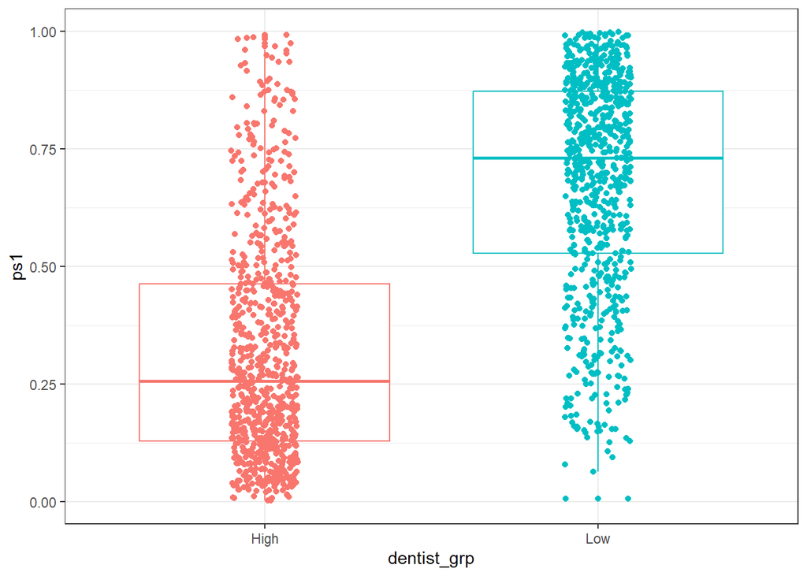

```r
ggplot(chr_fin2, aes(x = dentist_grp, y = ps1, color = dentist_grp)) +
    geom_boxplot() +
    geom_jitter(width = 0.1) +
    guides(color = "none")
```

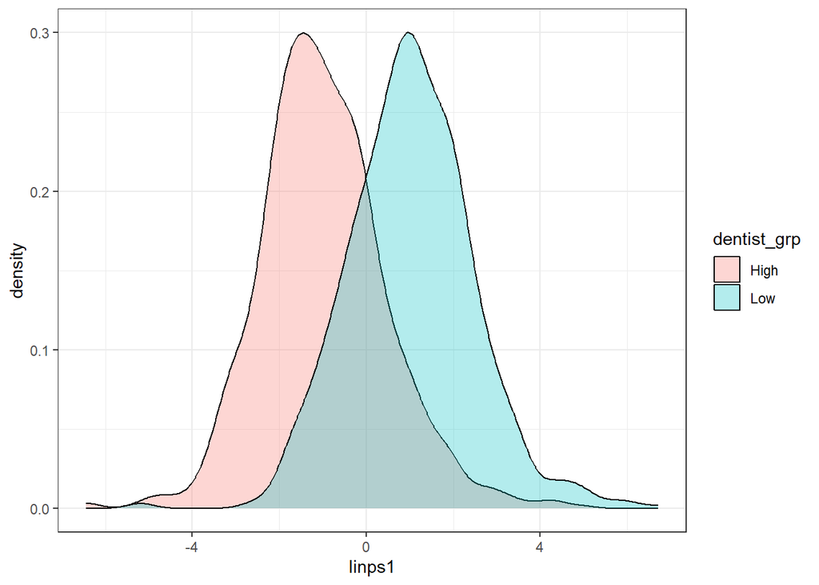

```r
ggplot(chr_fin2, aes(x = linps1, fill = dentist_grp)) +
    geom_density(alpha = 0.3)
```

> There is a good overlap between the two groups.

### 6.1.1 Rubin’s Rule 1

```r
rubin1.unadj <- with(chr_fin2,
     abs(100*(mean(linps1[dentist_n==1])-mean(linps1[dentist_n==0]))/sd(linps1)))
rubin1.unadj
```

```
[1] 114.7657
```

The absolute value of the standardized difference of the linear propensity score comparing the counties with high dentist proportions and low dentist proportions is 114.8%. This value is too far from the ideal value of 0% and above the maximum acceptable value of 50 %. We definitely do not pass Rubin’s rule 1, therefore, propensity score adjustment is needed.

### 6.1.2 Rubin’s Rule 2

```r
rubin2.unadj <-with(chr_fin2, var(linps1[dentist_n==1])/var(linps1[dentist_n==0]))
rubin2.unadj
```

```
[1] 0.9818352
```

The ratio of variances of the linear propensity score comparing the counties with high dentist proportions and low dentist proportions is 0.98. This value is very close to the desired value of 1.0. In this case, we pass Rubin’s Rule 2.

## 6.2 Unadjusted Outcome 1 `smoking_prop`

We will observe the the distribution of the outcome `smoking_prop` among the two exposure groups `dentist_grp`.

```r
df_stats(smoking_prop ~ dentist_grp, data = chr_fin2) |>
  gt() |> fmt_number(mean:sd, decimals = 2) |>
  opt_stylize(style = 5, color = "pink")
```

| response | dentist_grp | min | Q1 | median | Q3 | max | mean | sd | n | missing |
| --- | --- | --- | --- | --- | --- | --- | --- | --- | --- | --- |
| smoking_prop | High | 6.821752 | 14.04568 | 15.86923 | 18.30110 | 37.02901 | 16.41 | 3.68 | 777 | 0 |
| smoking_prop | Low | 7.687424 | 15.68921 | 18.72868 | 21.37735 | 41.20176 | 18.78 | 3.76 | 777 | 0 |

The high dentist group has a lower mean of smoking proportions (16.4 vs 18.8).

### 6.2.1 Linear Regression Model for Outcome 1

We will build a linear regression model for outcome 1 `smoking_prop` and the exposure `dentist_prop` without including the covariates.

```r
unadj.out1 <- lm(smoking_prop ~ dentist_grp, data= chr_fin2)

model_parameters(unadj.out1, ci = 0.95) |>
  gt() |> fmt_number(columns = -df_error, decimals = 3) |>
  opt_stylize(style = 6, color = "pink")
```

| Parameter | Coefficient | SE | CI | CI_low | CI_high | t | df_error | p |
| --- | --- | --- | --- | --- | --- | --- | --- | --- |
| (Intercept) | 16.412 | 0.133 | 0.950 | 16.150 | 16.673 | 123.071 | 1552 | 0.000 |
| dentist_grpLow | 2.364 | 0.189 | 0.950 | 1.994 | 2.734 | 12.533 | 1552 | 0.000 |

> The unadjusted model estimates that low dentist proportions increases smoking prevalence in US counties by 2.36 percentage points (95% CI: 1.99, 2.73).

## 6.3 1:1 Matching With Replacement

The binary exposure has an equal number of observations in each group (n=777). Therefore, we will use 1:1 matching with replacement.

```r
X <- chr_fin2$linps1
Tr <- as.logical(chr_fin2$dentist_n)
match1 <- Match(Tr=Tr, X=X, M = 1, replace = TRUE, ties=FALSE)
summary(match1)
```

```
Estimate...  0
SE.........  0
T-stat.....  NaN
p.val......  NA

Original number of observations..............  1554
Original number of treated obs...............  777
Matched number of observations...............  777
Matched number of observations  (unweighted).  777
```

checking if matching worked:

```r
n_distinct(match1$index.treated)
```

```
[1] 777
```

```r
n_distinct(match1$index.control)
```

```
[1] 278
```

### 6.3.1 Balance Assessment

```r
set.seed(500)
mb1 <- MatchBalance(dentist_n ~ poor_mental + unemployment  + income_inequality + social_score +
                  diabetes  + insuff_sleep + highschool_grad + segregation +
                  below_18 + above_65 + ps1 + linps1,
                  data= chr_fin2,
                    match.out = match1, nboots=500)
```

```
***** (V1) poor_mental *****
                       Before Matching       After Matching
mean treatment........      5.354             5.354
mean control..........     5.0152            5.2984
std mean diff.........     52.617            8.6282

mean raw eQQ diff.....    0.34041          0.082562
med  raw eQQ diff.....    0.36298          0.073533
max  raw eQQ diff.....    0.73693           0.73693

mean eCDF diff........    0.16003          0.034772
med  eCDF diff........    0.18919          0.027027
max  eCDF diff........    0.24324           0.10296

var ratio (Tr/Co).....       1.18            1.0251
T-test p-value........ < 2.22e-16          0.068521
KS Bootstrap p-value.. < 2.22e-16             0.002
KS Naive p-value...... < 2.22e-16        0.00052946
KS Statistic..........    0.24324           0.10296


***** (V2) unemployment *****
                       Before Matching       After Matching
mean treatment........   0.035706          0.035706
mean control..........   0.034857          0.035613
std mean diff.........     7.1471           0.77874

mean raw eQQ diff.....  0.0010747         0.0010116
med  raw eQQ diff.....   0.001005        0.00071892
max  raw eQQ diff.....   0.013165          0.018658

mean eCDF diff........   0.025066          0.020112
med  eCDF diff........   0.020592          0.015444
max  eCDF diff........   0.059202          0.065637

var ratio (Tr/Co).....     1.0862            1.0782
T-test p-value........    0.15077            0.8748
KS Bootstrap p-value..      0.146             0.072
KS Naive p-value......    0.13128          0.070342
KS Statistic..........   0.059202          0.065637
```

[output cut: 202 more lines]

```
med  eCDF diff........    0.38867          0.001287
max  eCDF diff........    0.56113          0.019305

var ratio (Tr/Co).....    0.98184            1.0325
T-test p-value........ < 2.22e-16          0.035311
KS Bootstrap p-value.. < 2.22e-16                 1
KS Naive p-value...... < 2.22e-16           0.99869
KS Statistic..........    0.56113          0.019305


Before Matching Minimum p.value: < 2.22e-16
Variable Name(s): poor_mental social_score diabetes insuff_sleep highschool_grad segregation above_65 ps1 linps1  Number(s): 1 4 5 6 7 8 10 11 12

After Matching Minimum p.value: < 2.22e-16
Variable Name(s): insuff_sleep highschool_grad segregation above_65  Number(s): 6 7 8 10
```

### 6.3.2 Tabulating Standardized Differences

We will name the covariates used in our model.

```r
covnames <- c( "poor_mental", "unemployment", "income_inequality", "social_score",
                  "diabetes", "insuff_sleep", "highschool_grad", "segregation",
                  "below_18", "above_65", "raw PS", "linear PS")
```

Then we will extract the standardized differences.

```r
pre.szd <- NULL; post.szd <- NULL
for(i in 1:length(covnames)) {
  pre.szd[i] <- mb1$BeforeMatching[[i]]$sdiff.pooled
  post.szd[i] <- mb1$AfterMatching[[i]]$sdiff.pooled
}
```

Now, we can have our final table.

```r
match_szd <- tibble(covnames, pre.szd, post.szd, row.names=covnames)
match_szd
```

```
# A tibble: 12 × 4
   covnames          pre.szd post.szd row.names
   <chr>               <dbl>    <dbl> <chr>
 1 poor_mental         54.7    8.63   poor_mental
 2 unemployment         7.29   0.779  unemployment
 3 income_inequality    8.73  -0.755  income_inequality
 4 social_score        -1.95  -5.87   social_score
 5 diabetes            78.8    4.58   diabetes
 6 insuff_sleep        70.3   -3.62   insuff_sleep
 7 highschool_grad     36.8    7.35   highschool_grad
 8 segregation        -67.0  -20.5    segregation
 9 below_18             2.43  -0.605  below_18
10 above_65            39.4  -21.1    above_65
11 raw PS             153.    -0.0179 raw PS
12 linear PS          140.     0.503  linear PS
```

We will use these results to build the love plot to better visualize the standardized differences.

### 6.3.3 Visualizing Standardized Differences

We will use the cobalt method to build plots for the standardized differences and the variance ratios.

```r
b <- bal.tab(match1,
             dentist_n ~ poor_mental + unemployment  + income_inequality + social_score +
                  diabetes  + insuff_sleep + highschool_grad + segregation +
                  below_18 + above_65 + ps1 + linps1,
             data= chr_fin2, stats = c("m", "v"), un = TRUE,
             quick = FALSE)
b
```

```
Balance Measures
                     Type Diff.Un V.Ratio.Un Diff.Adj V.Ratio.Adj
poor_mental       Contin.  0.5262     1.1800   0.0863      1.0184
unemployment      Contin.  0.0715     1.0862   0.0078      1.0711
income_inequality Contin.  0.0780     1.6836  -0.0075      1.5929
social_score      Contin. -0.0168     2.0485  -0.0587      1.2064
diabetes          Contin.  0.7114     1.5867   0.0458      1.0249
insuff_sleep      Contin.  0.6869     1.1012  -0.0362      0.7283
highschool_grad   Contin.  0.3478     1.2754   0.0735      1.4175
segregation       Contin. -0.6076     1.5551  -0.2048      1.2258
below_18          Contin.  0.0238     1.0897  -0.0060      0.9618
above_65          Contin.  0.3989     0.9554  -0.2111      0.5852
ps1               Contin.  1.5579     0.9335  -0.0002      0.9934
linps1            Contin.  1.4076     0.9818   0.0050      1.0257

Sample sizes
                     Control Treated
All                   777.       777
Matched (ESS)         127.23     777
Matched (Unweighted)  278.       777
Unmatched             499.         0
```

Now we will build the love plot for the standardized differences:

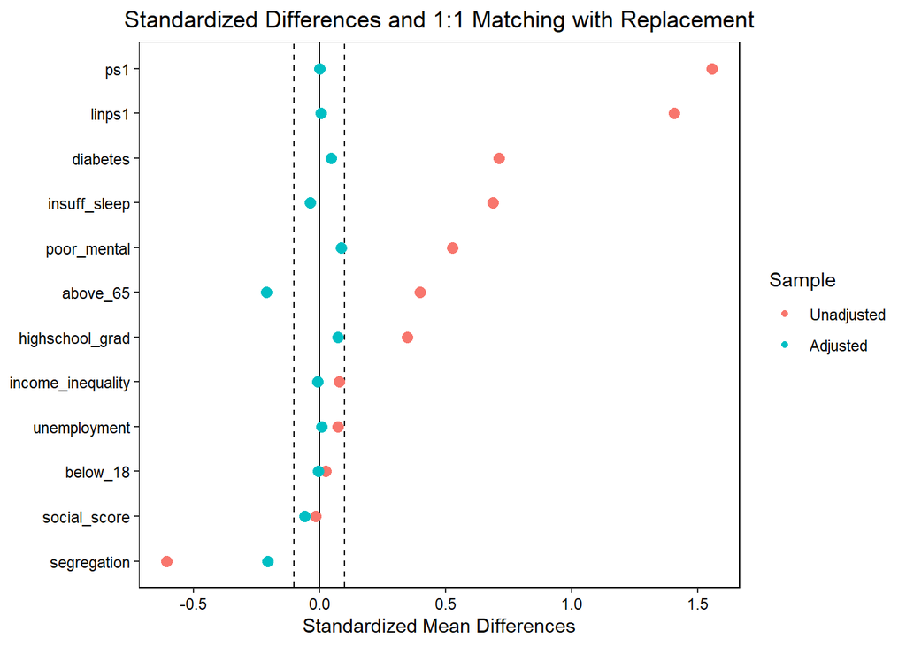

```r
lplot1 <- love.plot(b, threshold = .1, size = 3,
               var.order = "unadjusted", stars = "raw",
               title = "Standardized Differences and 1:1 Matching with Replacement")
lplot1
```

> All covariates have improved standardized difference after 1:1 matching adjustment, with the exception for `social_score.`

Plot of Variance Ratios

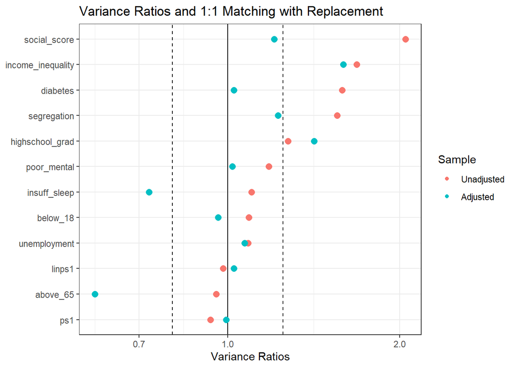

```r
lplot2 <- love.plot(b, stat = "v",
               threshold = 1.25, size = 3,
               var.order = "unadjusted",
               title = "Variance Ratios and 1:1 Matching with Replacement")
lplot2 + theme_bw()
```

### 6.3.4 Building New Data Frame with Matched Sample

```r
matches1 <- factor(rep(match1$index.treated, 2))
chr.matchedsample1 <- cbind(matches1, chr_fin2[c(match1$index.control, match1$index.treated),])
```

```r
chr.matchedsample1 |> count(dentist_grp)
```

```
  dentist_grp   n
1        High 777
2         Low 777
```

Because the 1:1 matching method we used includes *replacement*, it is only natural to retain the original number of observations in the exposure groups.

### 6.3.5 Rubin’s Rules After Matching

First, we will check Rubin’s Rule 1:

```r
rubin1.match1 <- with(chr.matchedsample1,
      abs(100*(mean(linps1[dentist_n==1])-mean(linps1[dentist_n==0]))/sd(linps1)))
rubin1.match1
```

```
[1] 0.5067778
```

Next, we will check Rubin’s Rule 2:

```r
rubin2.match1 <- with(chr.matchedsample1, var(linps1[dentist_n==1])/var(linps1[dentist_n==0]))
rubin2.match1
```

```
[1] 1.032521
```

### 6.3.6 Estimating Effect of Exposure on Outcome After 1:1 Matching

We will use the ATT (Average Treatment Effect on the Treated) estimate to measure the dentist proportion effect on smoking prevalence in US Counties. First, we will need to create a data frame out of the matched sample:

```r
matches1 <- factor(rep(match1$index.treated, 2))
chr.matchedsamplef <- cbind(matches1, chr_fin2[c(match1$index.control, match1$index.treated),])
```

Now, we can produce an estimate using the matched sample from `chr_fin2`.

```r
chr.matchedsamplef$matches.f <- as.factor(chr.matchedsamplef$matches1)

matched_mix.mod1 <- lmer(smoking_prop ~ dentist_n + (1 | matches.f), REML = TRUE, data=chr.matchedsamplef)

tidy_matched_mix.mod1 <- broom.mixed::tidy(matched_mix.mod1, conf.int = TRUE, conf.level = 0.95) |>
  filter(term == "dentist_n")

tidy_matched_mix.mod1 |> kable(digits = 3)
```

| effect | group | term | estimate | std.error | statistic | conf.low | conf.high |
| --- | --- | --- | --- | --- | --- | --- | --- |
| fixed | NA | dentist_n | 0.776 | 0.195 | 3.985 | 0.394 | 1.158 |

> After 1:1 matching with replacement, our model estimates the effect of low dentists proportions on smoking prevalence in US counties to increase by 0.78 percentage points (95% CI: 0.39, 1.16). Our confidence interval does not include 0, therefore, following up with a sensitivity analysis is a reasonable choice.

## 6.4 Use ATT Weighting Adjustment

We will start by creating a data frame of our data set.

```r
chrfin_df <- base::data.frame(chr_fin2)
```

Now, we will calculate the propensity score using the `ps` function from the `twang` package.

```r
ps.chr <- twang::ps(dentist_n ~ poor_mental + unemployment  + income_inequality + social_score +
                  diabetes  + insuff_sleep + highschool_grad + segregation +
                  below_18 + above_65 + ps1 + linps1,
             data = chrfin_df,
             n.trees = 5000,
             interaction.depth = 2,
             stop.method = c("es.mean"),
             estimand = "ATT",
             verbose = FALSE)
```

Checking the iteration:

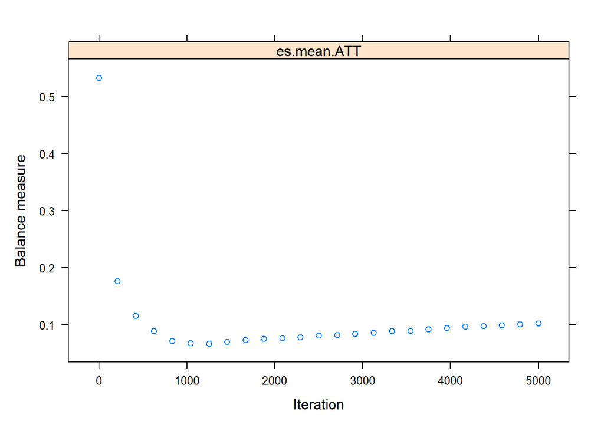

```r
plot(ps.chr)
```

> We can see that we have run enough iterations to reach a stable estimate.

Observing the effective sample size of the weighted estimates:

```r
summary(ps.chr)
```

```
            n.treat n.ctrl ess.treat ess.ctrl    max.es   mean.es    max.ks
unw             777    777       777 777.0000 1.5578591 0.5361848 0.5611326
es.mean.ATT     777    777       777 163.8941 0.1794596 0.0667433 0.1205385
            max.ks.p    mean.ks iter
unw               NA 0.26490776   NA
es.mean.ATT       NA 0.07668971 1111
```

> The effective size after ATT weighting is 163 counties.

### 6.4.1 Checking the balance

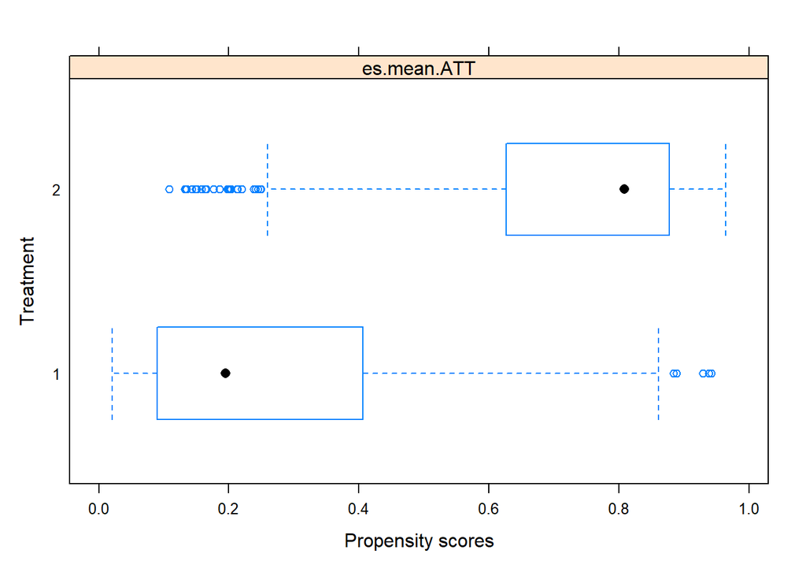

```r
plot(ps.chr, plots = 2)
```

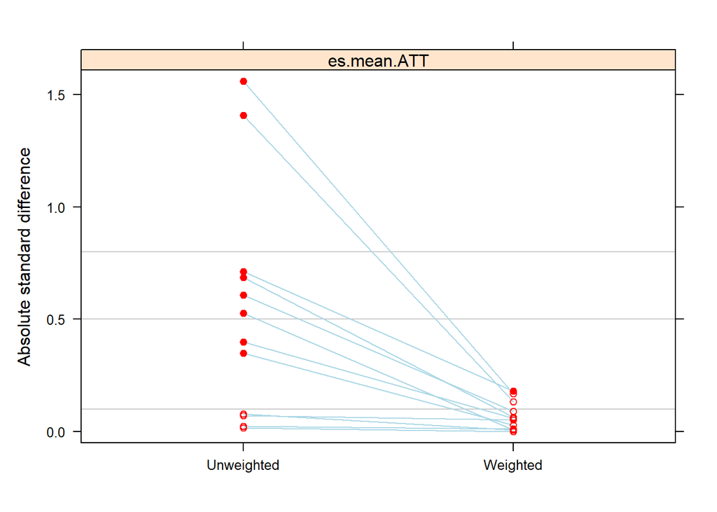

```r
plot(ps.chr, plots = 3)
```

> We can see that the weighted estimates have an absolute standard differences are below 0.5 and are closer to 0 compared to the unadjusted estimates.

We can also assess the balance using the cobalt method.

```r
b2 <- cobalt::bal.tab(ps.chr, full.stop.method = "es.mean.att",
        stats = c("m", "v"), un = TRUE)

b2
```

```
Balance Measures
                      Type Diff.Un V.Ratio.Un Diff.Adj V.Ratio.Adj
prop.score        Distance  2.2674     0.7698   0.5561      0.6932
poor_mental        Contin.  0.5262     1.1800   0.0079      0.9499
unemployment       Contin.  0.0715     1.0862   0.0512      1.1563
income_inequality  Contin.  0.0780     1.6836   0.0068      1.3792
social_score       Contin. -0.0168     2.0485   0.0007      1.0241
diabetes           Contin.  0.7114     1.5867   0.1795      1.4289
insuff_sleep       Contin.  0.6869     1.1012   0.0630      0.9451
highschool_grad    Contin.  0.3478     1.2754  -0.0281      1.3991
segregation        Contin. -0.6076     1.5551  -0.0901      0.9325
below_18           Contin.  0.0238     1.0897  -0.0110      1.0725
above_65           Contin.  0.3989     0.9554  -0.0601      0.8466
ps1                Contin.  1.5579     0.9335   0.1684      0.8879
linps1             Contin.  1.4076     0.9818   0.1342      0.8905

Effective sample sizes
           Control Treated
Unadjusted  777.       777
Adjusted    163.89     777
```

We will visualize the standardized differences using the Love plot.

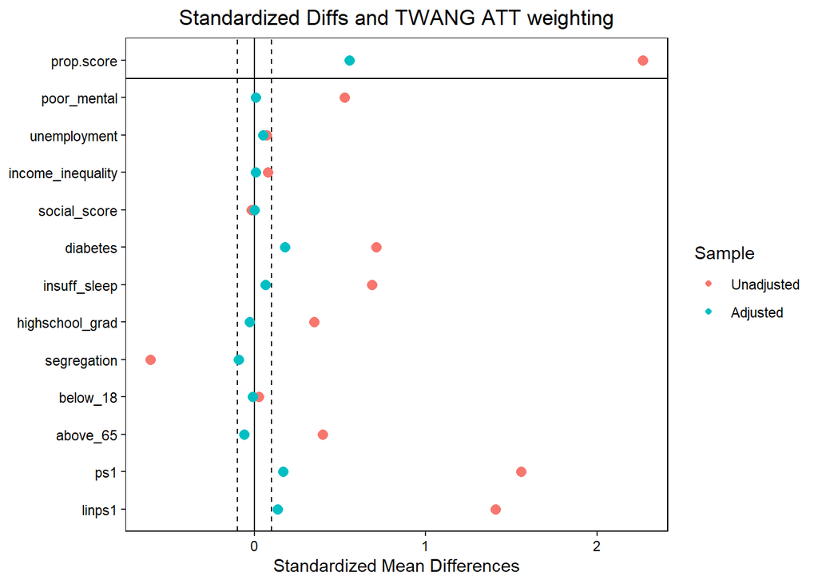

```r
lplot3 <- cobalt::love.plot(b2,
               threshold = .1, size = 3, stars = "raw",
               title = "Standardized Diffs and TWANG ATT weighting")
lplot3
```

> All of the variables have observable improved standardized difference after TWANG ATT weighting adjustment.

Visualizing the variance ratio:

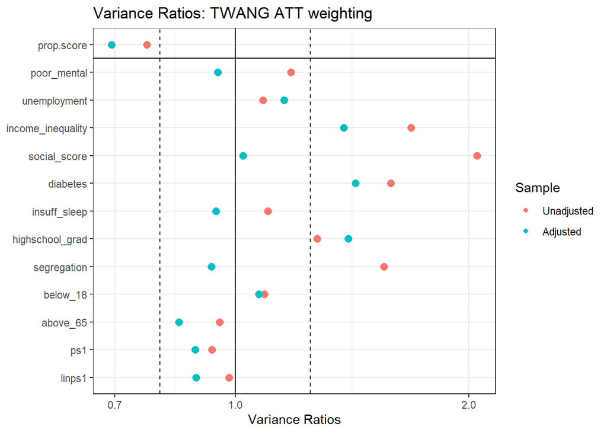

```r
lplot4 <- cobalt::love.plot(b2, stat = "v",
               threshold = 1.25, size = 3,
               title = "Variance Ratios: TWANG ATT weighting")
lplot4 + theme_bw()
```

Most of the variables show some improvement in the variance ration after adjustment, though it is not very satisfying.

### 6.4.2 Estimating The Causal Effect After ATT Weight Adjustment

```r
chr_fin2$wts1 <- ifelse(chr_fin2$dentist_n==1, 1, chr_fin2$ps1/(1-chr_fin2$ps1))
```

```r
chrwt1.design <- survey::svydesign(ids=~1, weights=~wts1, data= chr_fin2)

adjout1.wt1 <- survey::svyglm(smoking_prop ~ dentist_n, design= chrwt1.design)

wt_att_results1 <- tidy(adjout1.wt1, conf.int = TRUE) |> filter(term == "dentist_n")

wt_att_results1
```

```
# A tibble: 1 × 7
  term      estimate std.error statistic p.value conf.low conf.high
  <chr>        <dbl>     <dbl>     <dbl>   <dbl>    <dbl>     <dbl>
1 dentist_n   -0.434      1.09    -0.398   0.691    -2.57      1.71
```

> After ATT weight adjustment, the estimated impact of low dentist proportions on smoking prevalence in US counties is decrease of -0.43 percentage points (95% CI: -2.57, 1.71).

## 6.5 Use Double Robust Adjustment

```r
chr.dr.design <- survey::svydesign(ids=~1, weights=~wts1, data= chr_fin2)

dr.out1.wt1 <- survey::svyglm(smoking_prop ~ dentist_n + linps1, design= chr.dr.design)

dr_att_out1 <- tidy(dr.out1.wt1, conf.int = TRUE) |> filter(term == "dentist_n")

dr_att_out1
```

```
# A tibble: 1 × 7
  term      estimate std.error statistic p.value conf.low conf.high
  <chr>        <dbl>     <dbl>     <dbl>   <dbl>    <dbl>     <dbl>
1 dentist_n    0.723     0.453      1.60   0.111   -0.166      1.61
```

## 6.6 Compare Results

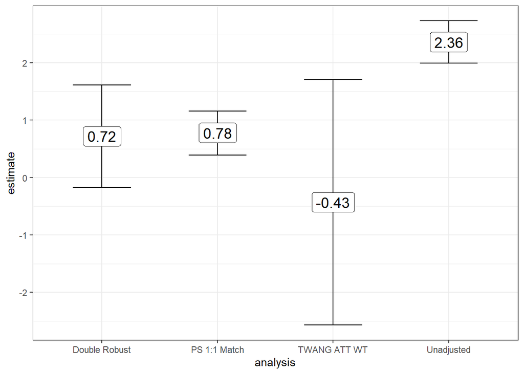

```r
chr_results <- tibble(
    analysis = c("Unadjusted", "PS 1:1 Match", "TWANG ATT WT", "Double Robust"),
    estimate = c(2.36, 0.78, -0.43, 0.72),
    conf.low = c(1.99, 0.39, -2.57, -0.17),
    conf.high = c(2.73, 1.16, 1.71, 1.61))

ggplot(chr_results, aes(x = analysis, y = estimate)) +
    geom_errorbar(aes(ymax = conf.high, ymin = conf.low), width = 0.5) +
    geom_label(aes(label = estimate), size = 5)
```

## 6.7 Sensitivity Analysis

The estimate produced from the 1:1 Matching with replacement has a statistically significant p-value. Therefore, we will need to perform a sensitivity analysis.

```r
Rc <- match1$mdata$Y[match1$mdata$Tr==0]
Rt <- match1$mdata$Y[match1$mdata$Tr==1]


psens(Rt, Rc, Gamma = 5, GammaInc = 0.25)
```

```
 Rosenbaum Sensitivity Test for Wilcoxon Signed Rank P-Value

Unconfounded estimate ....  NaN

 Gamma Lower bound Upper bound
  1.00         NaN         NaN
  1.25         NaN         NaN
  1.50         NaN         NaN
  1.75         NaN         NaN
  2.00         NaN         NaN
  2.25         NaN         NaN
  2.50         NaN         NaN
  2.75         NaN         NaN
  3.00         NaN         NaN
  3.25         NaN         NaN
  3.50         NaN         NaN
  3.75         NaN         NaN
  4.00         NaN         NaN
  4.25         NaN         NaN
  4.50         NaN         NaN
  4.75         NaN         NaN
  5.00         NaN         NaN

 Note: Gamma is Odds of Differential Assignment To
 Treatment Due to Unobserved Factors
```

# 7 Outcome 2 Analysis

## 7.1 Unadjusted Outcome 2 `drinking_prop`

We will observe the the distribution of the outcome `drinking_prop` among the two exposure groups `dentist_grp`.

```r
df_stats(drinking_prop ~ dentist_grp, data = chr_fin2) |>
  gt() |> fmt_number(mean:sd, decimals = 2) |>
  opt_stylize(style = 5, color = "pink")
```

| response | dentist_grp | min | Q1 | median | Q3 | max | mean | sd | n | missing |
| --- | --- | --- | --- | --- | --- | --- | --- | --- | --- | --- |
| drinking_prop | High | 10.140012 | 16.79649 | 18.88142 | 20.74658 | 29.44012 | 18.83 | 3.24 | 777 | 0 |
| drinking_prop | Low | 9.265156 | 14.09065 | 16.03230 | 18.32060 | 27.81331 | 16.26 | 2.91 | 777 | 0 |

The low dentist group has a lower mean of excessive drinking prevalence (16.3 vs 18.8).

### 7.1.1 Linear Regression Model for Outcome 2

We will build a linear regression model for outcome 2 `drinking_prop` and the exposure `dentist_grp` without including the covariates.

```r
unadj.out2 <- lm(drinking_prop ~ dentist_grp, data= chr_fin2)

model_parameters(unadj.out2, ci = 0.95) |>
  gt() |> fmt_number(columns = -df_error, decimals = 3) |>
  opt_stylize(style = 6, color = "pink")
```

| Parameter | Coefficient | SE | CI | CI_low | CI_high | t | df_error | p |
| --- | --- | --- | --- | --- | --- | --- | --- | --- |
| (Intercept) | 18.825 | 0.110 | 0.950 | 18.609 | 19.042 | 170.493 | 1552 | 0.000 |
| dentist_grpLow | −2.563 | 0.156 | 0.950 | −2.869 | −2.256 | −16.412 | 1552 | 0.000 |

> The unadjusted model estimates that low dentist proportions decreases excessive drinking prevalence in US counties by 2.56 percentage points (95% CI: -2.87, -2.26).

## 7.2 1:1 Matching With Replacement

The binary exposure has an equal number of observations in each group (n=777). Therefore, we will use 1:1 matching with replacement.

```r
X <- chr_fin2$linps1
Tr <- as.logical(chr_fin2$dentist_n)
match2 <- Match(Tr=Tr, X=X, M = 1, replace = TRUE, ties=FALSE)
summary(match2)
```

```
Estimate...  0
SE.........  0
T-stat.....  NaN
p.val......  NA

Original number of observations..............  1554
Original number of treated obs...............  777
Matched number of observations...............  777
Matched number of observations  (unweighted).  777
```

checking if matching worked:

```r
n_distinct(match2$index.treated)
```

```
[1] 777
```

```r
n_distinct(match2$index.control)
```

```
[1] 269
```

> After 1:1 matching with replacement, the effective size was reduced to 269 matched counties from the low dentist and high dentist groups.

### 7.2.1 Balance Assessment

```r
set.seed(500)
mb2 <- MatchBalance(dentist_n ~ poor_mental + unemployment  + income_inequality + social_score +
                  diabetes  + insuff_sleep + highschool_grad + segregation +
                  below_18 + above_65 + ps1 + linps1,
                  data= chr_fin2,
                    match.out = match2, nboots=500)
```

```
***** (V1) poor_mental *****
                       Before Matching       After Matching
mean treatment........      5.354             5.354
mean control..........     5.0152            5.3006
std mean diff.........     52.617            8.2912

mean raw eQQ diff.....    0.34041          0.078434
med  raw eQQ diff.....    0.36298          0.068421
max  raw eQQ diff.....    0.73693           0.73693

mean eCDF diff........    0.16003          0.033382
med  eCDF diff........    0.18919           0.02574
max  eCDF diff........    0.24324           0.10296

var ratio (Tr/Co).....       1.18            1.0018
T-test p-value........ < 2.22e-16          0.081108
KS Bootstrap p-value.. < 2.22e-16             0.002
KS Naive p-value...... < 2.22e-16        0.00052946
KS Statistic..........    0.24324           0.10296


***** (V2) unemployment *****
                       Before Matching       After Matching
mean treatment........   0.035706          0.035706
mean control..........   0.034857          0.035517
std mean diff.........     7.1471            1.5883

mean raw eQQ diff.....  0.0010747        0.00088258
med  raw eQQ diff.....   0.001005        0.00061619
max  raw eQQ diff.....   0.013165          0.018658

mean eCDF diff........   0.025066          0.017423
med  eCDF diff........   0.020592           0.01287
max  eCDF diff........   0.059202          0.055341

var ratio (Tr/Co).....     1.0862            1.1023
T-test p-value........    0.15077            0.7428
KS Bootstrap p-value..      0.146             0.178
KS Naive p-value......    0.13128           0.18502
KS Statistic..........   0.059202          0.055341
```

[output cut: 202 more lines]

```
med  eCDF diff........    0.38867          0.001287
max  eCDF diff........    0.56113          0.019305

var ratio (Tr/Co).....    0.98184            1.0326
T-test p-value........ < 2.22e-16          0.030659
KS Bootstrap p-value.. < 2.22e-16                 1
KS Naive p-value...... < 2.22e-16           0.99869
KS Statistic..........    0.56113          0.019305


Before Matching Minimum p.value: < 2.22e-16
Variable Name(s): poor_mental social_score diabetes insuff_sleep highschool_grad segregation above_65 ps1 linps1  Number(s): 1 4 5 6 7 8 10 11 12

After Matching Minimum p.value: < 2.22e-16
Variable Name(s): insuff_sleep highschool_grad segregation above_65  Number(s): 6 7 8 10
```

### 7.2.2 Tabulating Standardized Differences

We will name the covariates used in our model.

```r
covnames2 <- c( "poor_mental", "unemployment", "income_inequality", "social_score",
                  "diabetes", "insuff_sleep", "highschool_grad", "segregation",
                  "below_18", "above_65", "raw PS", "linear PS")
```

Then we will extract the standardized differences.

```r
pre.szd2 <- NULL; post.szd2 <- NULL
for(i in 1:length(covnames2)) {
  pre.szd2[i] <- mb2$BeforeMatching[[i]]$sdiff.pooled
  post.szd2[i] <- mb2$AfterMatching[[i]]$sdiff.pooled
}
```

Now, we can have our final table.

```r
match_szd2 <- tibble(covnames2, pre.szd2, post.szd2, row.names=covnames2)
match_szd2
```

```
# A tibble: 12 × 4
   covnames2         pre.szd2 post.szd2 row.names
   <chr>                <dbl>     <dbl> <chr>
 1 poor_mental          54.7    8.29    poor_mental
 2 unemployment          7.29   1.59    unemployment
 3 income_inequality     8.73  -2.83    income_inequality
 4 social_score         -1.95  -6.19    social_score
 5 diabetes             78.8    2.33    diabetes
 6 insuff_sleep         70.3   -4.47    insuff_sleep
 7 highschool_grad      36.8    4.50    highschool_grad
 8 segregation         -67.0  -20.7     segregation
 9 below_18              2.43  -3.17    below_18
10 above_65             39.4  -16.9     above_65
11 raw PS              153.    -0.00113 raw PS
12 linear PS           140.     0.516   linear PS
```

We will use these results to build the love plot to better visualize the standardized differences.

### 7.2.3 Visualizing Standardized Differences

We will use the cobalt method to build plots for the standardized differences and the variance ratios.

```r
b2 <- bal.tab(match2,
             dentist_n ~ poor_mental + unemployment  + income_inequality + social_score +
                  diabetes  + insuff_sleep + highschool_grad + segregation +
                  below_18 + above_65 + ps1 + linps1,
             data= chr_fin2, stats = c("m", "v"), un = TRUE,
             quick = FALSE)
b2
```

```
Balance Measures
                     Type Diff.Un V.Ratio.Un Diff.Adj V.Ratio.Adj
poor_mental       Contin.  0.5262     1.1800   0.0829      0.9952
unemployment      Contin.  0.0715     1.0862   0.0159      1.0950
income_inequality Contin.  0.0780     1.6836  -0.0283      1.4904
social_score      Contin. -0.0168     2.0485  -0.0619      1.2062
diabetes          Contin.  0.7114     1.5867   0.0233      1.0329
insuff_sleep      Contin.  0.6869     1.1012  -0.0447      0.7511
highschool_grad   Contin.  0.3478     1.2754   0.0450      1.7271
segregation       Contin. -0.6076     1.5551  -0.2071      1.2381
below_18          Contin.  0.0238     1.0897  -0.0317      0.9721
above_65          Contin.  0.3989     0.9554  -0.1692      0.5954
ps1               Contin.  1.5579     0.9335  -0.0000      0.9933
linps1            Contin.  1.4076     0.9818   0.0052      1.0257

Sample sizes
                     Control Treated
All                    777.      777
Matched (ESS)          126.7     777
Matched (Unweighted)   269.      777
Unmatched              508.        0
```

> As previously mentioned, the effective size after 1:1 matching with replacement is 269 counties. We lost 508 counties from the sample because they were unmatched.

Now we will build the love plot for the standardized differences:

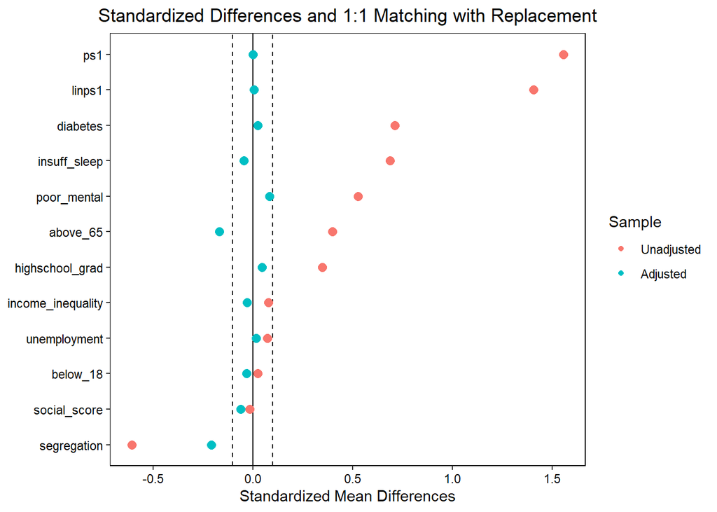

```r
lplot5 <- love.plot(b2, threshold = .1, size = 3,
               var.order = "unadjusted", stars = "raw",
               title = "Standardized Differences and 1:1 Matching with Replacement")
lplot5
```

Plot of Variance Ratios

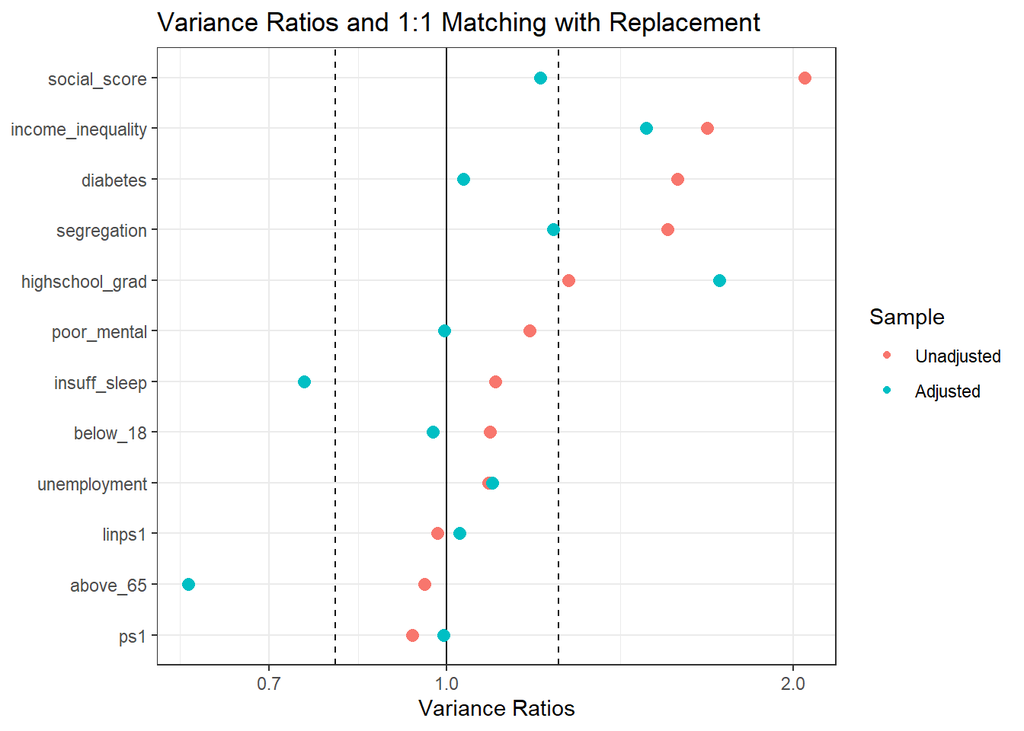

```r
lplot6 <- love.plot(b2, stat = "v",
               threshold = 1.25, size = 3,
               var.order = "unadjusted",
               title = "Variance Ratios and 1:1 Matching with Replacement")
lplot6 + theme_bw()
```

Most of the covariates displayed improved variance ratios with the exception of `highschool_grad`, `insuff_sleep`, `unemployment`, and `above_65`.

### 7.2.4 Building New Data Frame with Matched Sample

```r
matches2 <- factor(rep(match2$index.treated, 2))
chr.matchedsample2 <- cbind(matches2, chr_fin2[c(match2$index.control, match2$index.treated),])
```

```r
chr.matchedsample2 |> count(dentist_grp)
```

```
  dentist_grp   n
1        High 777
2         Low 777
```

Because the 1:1 matching method we used includes *replacement*, it is only natural to retain the original number of observations in the exposure groups.

### 7.2.5 Rubin’s Rules After Matching

First, we will check Rubin’s Rule 1:

```r
rubin1.match2 <- with(chr.matchedsample2,
      abs(100*(mean(linps1[dentist_n==1])-mean(linps1[dentist_n==0]))/sd(linps1)))
rubin1.match2
```

```
[1] 0.5203845
```

Next, we will check Rubin’s Rule 2:

```r
rubin2.match2 <- with(chr.matchedsample2, var(linps1[dentist_n==1])/var(linps1[dentist_n==0]))
rubin2.match2
```

```
[1] 1.032566
```

### 7.2.6 Estimating Effect of Exposure on Outcome After 1:1 Matching

```r
matches2 <- factor(rep(match2$index.treated, 2))
chr.matchedsamplef2 <- cbind(matches2, chr_fin2[c(match2$index.control, match2$index.treated),])
```

Now, we can produce an estimate using the matched sample from `chr_fin2`.

```r
chr.matchedsamplef2$matches2.f <- as.factor(chr.matchedsamplef2$matches2)

matched_mix.mod2 <- lmer(drinking_prop ~ dentist_n + (1 | matches2.f), REML = TRUE, data=chr.matchedsamplef2)

tidy_matched_mix.mod2 <- broom.mixed::tidy(matched_mix.mod2, conf.int = TRUE, conf.level = 0.95) |>
  filter(term == "dentist_n")

tidy_matched_mix.mod2 |> kable(digits = 3)
```

| effect | group | term | estimate | std.error | statistic | conf.low | conf.high |
| --- | --- | --- | --- | --- | --- | --- | --- |
| fixed | NA | dentist_n | 0.396 | 0.122 | 3.255 | 0.158 | 0.635 |

> After 1:1 matching with replacement, our model estimates the effect of low dentists proportions on excessive drinking prevalence in US counties to increase by 0.40 percentage points (95% CI: 0.16, 0.64). Our confidence interval does not include 0, therefore, following up with a sensitivity analysis is a reasonable choice.

## 7.3 Use ATT Weighting Adjustment

We will start by creating a data frame of our data set.

```r
chrfin_df2 <- base::data.frame(chr_fin2)
```

Now, we will calculate the propensity score using the `ps` function from the `twang` package.

```r
ps.chr2 <- twang::ps(dentist_n ~ poor_mental + unemployment  + income_inequality + social_score +
                  diabetes  + insuff_sleep + highschool_grad + segregation +
                  below_18 + above_65 + ps1 + linps1,
             data = chrfin_df2,
             n.trees = 5000,
             interaction.depth = 2,
             stop.method = c("es.mean"),
             estimand = "ATT",
             verbose = FALSE)
```

Checking the iteration:

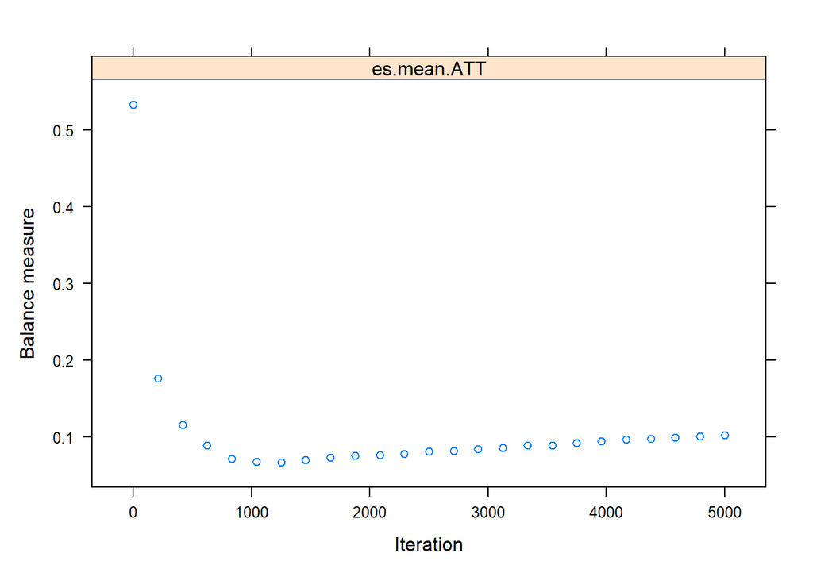

```r
plot(ps.chr2)
```

> We can see that we have run enough iterations to reach a stable estimate.

Observing the effective sample size of the weighted estimates:

```r
summary(ps.chr2)
```

```
            n.treat n.ctrl ess.treat ess.ctrl    max.es   mean.es    max.ks
unw             777    777       777 777.0000 1.5578591 0.5361848 0.5611326
es.mean.ATT     777    777       777 163.8941 0.1794596 0.0667433 0.1205385
            max.ks.p    mean.ks iter
unw               NA 0.26490776   NA
es.mean.ATT       NA 0.07668971 1111
```

> The effective size after ATT weighting is 163 counties.

### 7.3.1 Checking the balance

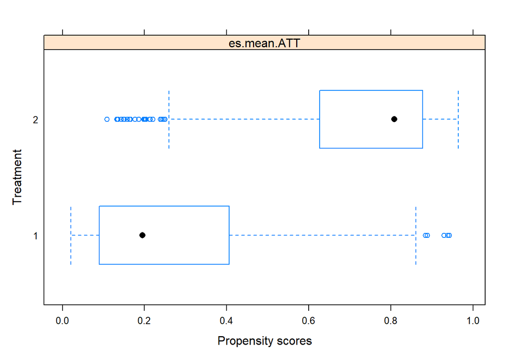

```r
plot(ps.chr2, plots = 2)
```

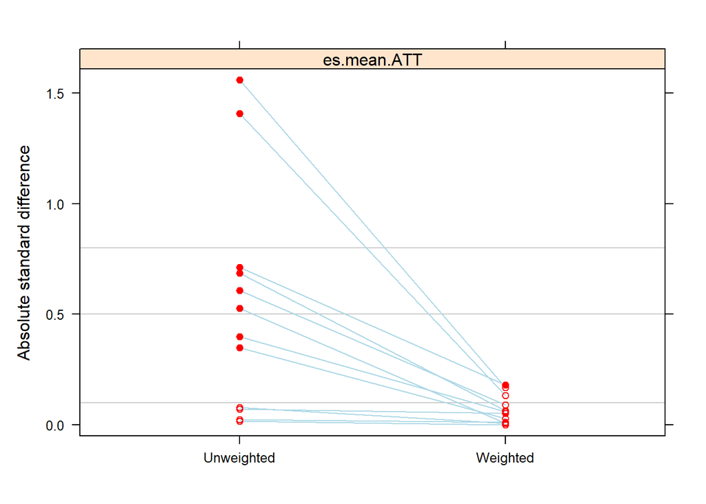

```r
plot(ps.chr2, plots = 3)
```

> We can see that the weighted estimates have an absolute standard differences are below 0.5 and are closer to 0 compared to the unadjusted estimates.

We can also assess the balance using the cobalt method.

```r
b3 <- cobalt::bal.tab(ps.chr2, full.stop.method = "es.mean.att",
        stats = c("m", "v"), un = TRUE)

b3
```

```
Balance Measures
                      Type Diff.Un V.Ratio.Un Diff.Adj V.Ratio.Adj
prop.score        Distance  2.2674     0.7698   0.5561      0.6932
poor_mental        Contin.  0.5262     1.1800   0.0079      0.9499
unemployment       Contin.  0.0715     1.0862   0.0512      1.1563
income_inequality  Contin.  0.0780     1.6836   0.0068      1.3792
social_score       Contin. -0.0168     2.0485   0.0007      1.0241
diabetes           Contin.  0.7114     1.5867   0.1795      1.4289
insuff_sleep       Contin.  0.6869     1.1012   0.0630      0.9451
highschool_grad    Contin.  0.3478     1.2754  -0.0281      1.3991
segregation        Contin. -0.6076     1.5551  -0.0901      0.9325
below_18           Contin.  0.0238     1.0897  -0.0110      1.0725
above_65           Contin.  0.3989     0.9554  -0.0601      0.8466
ps1                Contin.  1.5579     0.9335   0.1684      0.8879
linps1             Contin.  1.4076     0.9818   0.1342      0.8905

Effective sample sizes
           Control Treated
Unadjusted  777.       777
Adjusted    163.89     777
```

We will visualize the standardized differences using the Love plot.

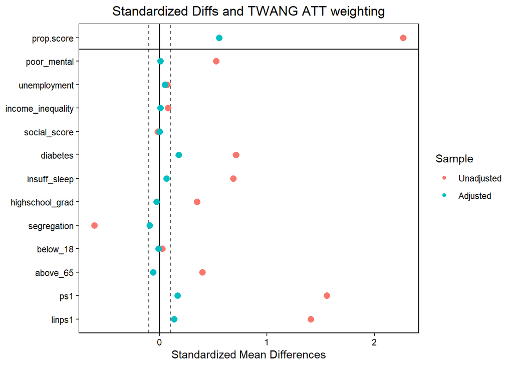

```r
lplot7 <- cobalt::love.plot(b3,
               threshold = .1, size = 3, stars = "raw",
               title = "Standardized Diffs and TWANG ATT weighting")
lplot7
```

> All of the variables have observable improved standardized difference after TWANG ATT weighting adjustment.

Visualizing the variance ratio:

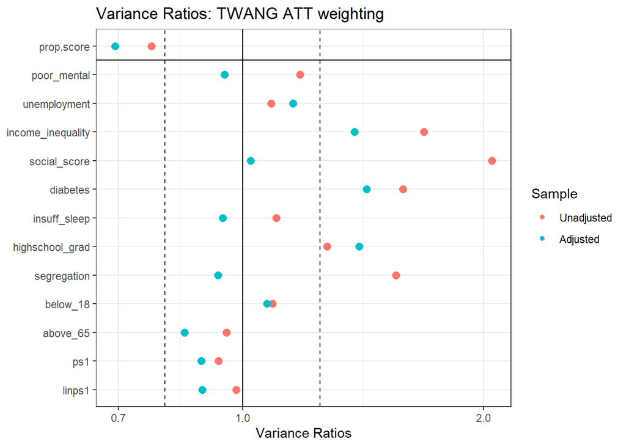

```r
lplot8 <- cobalt::love.plot(b3, stat = "v",
               threshold = 1.25, size = 3,
               title = "Variance Ratios: TWANG ATT weighting")
lplot8 + theme_bw()
```

Most of the variables show some improvement in the variance ration after adjustment, though it is not very satisfying.

### 7.3.2 Estimating The Causal Effect After ATT Weight Adjustment

We will use the weight design previously created `wt1` and `chrwt1.design`.

```r
adjout2.wt1 <- survey::svyglm(drinking_prop ~ dentist_n, design= chrwt1.design)

wt_att_results2 <- tidy(adjout2.wt1, conf.int = TRUE) |> filter(term == "dentist_n")

wt_att_results2
```

```
# A tibble: 1 × 7
  term      estimate std.error statistic p.value conf.low conf.high
  <chr>        <dbl>     <dbl>     <dbl>   <dbl>    <dbl>     <dbl>
1 dentist_n     1.15     0.520      2.20  0.0276    0.126      2.17
```

> After ATT weight adjustment, the estimated impact of low dentist proportions on excessive drinking prevalence in US counties is an increase of 1.15 percentage points (95% CI: 0.13, 2.17).

## 7.4 Use Double Robust Adjustment

We will use the previous double robust design `chr.dr.design`.

```r
dr.out2.wt1 <- survey::svyglm(drinking_prop ~ dentist_n + linps1, design= chr.dr.design)

dr_att_out2 <- tidy(dr.out2.wt1, conf.int = TRUE) |> filter(term == "dentist_n")

dr_att_out2
```

```
# A tibble: 1 × 7
  term      estimate std.error statistic p.value conf.low conf.high
  <chr>        <dbl>     <dbl>     <dbl>   <dbl>    <dbl>     <dbl>
1 dentist_n   -0.106     0.222    -0.477   0.633   -0.542     0.330
```

> After Double Robust adjustment, the estimated impact of low dentist proportions on excessive drinking prevalence in US counties is a decrease of -0.11 percentage points (95% CI: -0.54, 0.33). These results are very different from the ATT Weighting results.

## 7.5 Compare Results

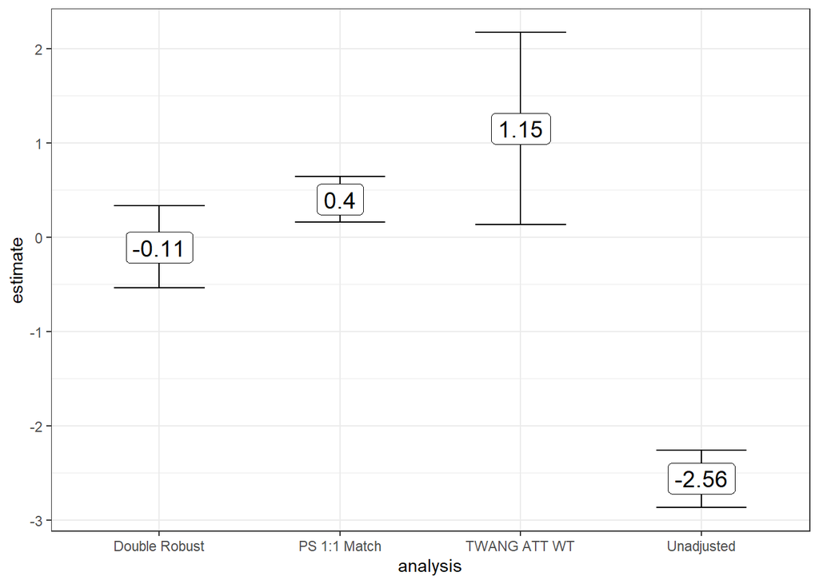

```r
chr_results2 <- tibble(
    analysis = c("Unadjusted", "PS 1:1 Match", "TWANG ATT WT", "Double Robust"),
    estimate = c(-2.56, 0.40, 1.15, -0.11),
    conf.low = c(-2.87, 0.16, 0.13, -0.54),
    conf.high = c(-2.26, 0.64, 2.17, 0.33))

ggplot(chr_results2, aes(x = analysis, y = estimate)) +
    geom_errorbar(aes(ymax = conf.high, ymin = conf.low), width = 0.5) +
    geom_label(aes(label = estimate), size = 5)
```

## 7.6 Sensitivity Analysis

The estimate produced from the 1:1 Matching with replacement has a statistically significant p-value. Therefore, we will need to perform a sensitivity analysis.

```r
Rc2 <- match2$mdata$Y[match2$mdata$Tr==0]
Rt2 <- match2$mdata$Y[match2$mdata$Tr==1]


psens(Rt2, Rc2, Gamma = 5, GammaInc = 0.25)
```

```
 Rosenbaum Sensitivity Test for Wilcoxon Signed Rank P-Value

Unconfounded estimate ....  NaN

 Gamma Lower bound Upper bound
  1.00         NaN         NaN
  1.25         NaN         NaN
  1.50         NaN         NaN
  1.75         NaN         NaN
  2.00         NaN         NaN
  2.25         NaN         NaN
  2.50         NaN         NaN
  2.75         NaN         NaN
  3.00         NaN         NaN
  3.25         NaN         NaN
  3.50         NaN         NaN
  3.75         NaN         NaN
  4.00         NaN         NaN
  4.25         NaN         NaN
  4.50         NaN         NaN
  4.75         NaN         NaN
  5.00         NaN         NaN

 Note: Gamma is Odds of Differential Assignment To
 Treatment Due to Unobserved Factors
```

# 8 Discussion

This project emphasized the importance of using confounders to assess selection biases in observational studies. The difference in the exposure’s effect estimates after propensity score adjustment was remarkable. While our initial belief was that having more covariates would improve the analysis, this project corrected that misconception. In our analysis, multiple covariates were dropped due to high correlation, collinearity, or for disrupting the propensity score values. Selecting and evaluating appropriate covariates was the most critical part for the propensity score analysis. To improve my study in the future, we will need to explore more variables from the County Health Rankings (CHR) as we may have missed other useful variables during the initial selection phase. Also, using the Health Professional Shortage Area classification (HPSA) instead of the number of dentists per population can provide a better assessment of the impact of dentist quantities on oral-related health behaviors in US counties.